# Counter Projection 4 Analyses

Kathryn Denning

1/20/2021

# Demographics & Descriptives

## Sample Size

### Overall:

```r
clean_ptcheck %>%
  select(sub_id) %>%
  unique() %>%
  nrow()
```

```
## [1] 618
```

### N per In/out-group

```r
clean_ptcheck %>%
  select(sub_id, group_cond) %>%
  unique() %>%
  group_by(group_cond) %>%
  count()
```

```
## # A tibble: 2 x 2
## # Groups:   group_cond [2]
##   group_cond     n
##   <fct>      <int>
## 1 In-group     311
## 2 Out-group    307
```

### N per Group & voting opinion

```r
clean_ptcheck %>%
  select(sub_id, group_cond, opin_pol_combined) %>%
  unique() %>%
  group_by(group_cond, opin_pol_combined) %>%
  count()
```

```
## # A tibble: 4 x 3
## # Groups:   group_cond, opin_pol_combined [4]
##   group_cond opin_pol_combined     n
##   <fct>      <fct>             <int>
## 1 In-group   Trump supporter      60
## 2 In-group   Anti Trump          251
## 3 Out-group  Trump supporter      59
## 4 Out-group  Anti Trump          248
```

## Gender

```r
clean_ptcheck %>%
  na.omit() %>%
  select(sub_id, gender) %>%
  mutate(gender = dplyr::recode(gender,
                         `1` = "Male",
                         `2` = "Female",
                         `3` = "Other")) %>%
  unique() %>%
  group_by(gender) %>%
  count()
```

```
## # A tibble: 3 x 2
## # Groups:   gender [3]
##   gender     n
##   <fct>  <int>
## 1 Male     240
## 2 Female   310
## 3 Other     13
```

## Race

```r
race_counts <- clean_ptcheck %>%
  select(sub_id, race) %>%
  na.omit() %>%
  mutate(race = dplyr::recode(race,
                       `1` = "American Indian/Alaska Native",
                       `2` = "Asian",
                       `3` = "Black",
                       `4` = "Latinx",
                       `5` = "Middle Eastern/North African",
                       `6` = "Caucasian",
                       `7` = "Multiracial",
                       `8` = "Other")) %>%
  unique() %>%
  group_by(race) %>%
  count()

race_counts %>%
  mutate(n_total = sum(race_counts$n),
    percent = n/n_total*100) %>%
  select(-n_total)
```

```
## # A tibble: 8 x 3
## # Groups:   race [8]
##   race                              n percent
##   <fct>                         <int>   <dbl>
## 1 American Indian/Alaska Native     3   0.487
## 2 Asian                            80  13.0
## 3 Black                            39   6.33
## 4 Latinx                           46   7.47
## 5 Middle Eastern/North African      1   0.162
## 6 Caucasian                       414  67.2
## 7 Multiracial                      28   4.55
## 8 Other                             5   0.812
```

## Age

```r
clean_ptcheck %>%
  select(sub_id, age) %>%
  na.omit() %>%
  summarize(mean = mean(age),
            sd = sd(age))
```

```
##       mean       sd
## 1 31.16306 11.44354
```

## Education

```r
edu_counts <- clean_ptcheck %>%
  select(sub_id, education) %>%
  na.omit() %>%
  mutate(education = dplyr::recode(education,
                                     `1` = "Less than high school",
                                     `2` = "High school graduate",
                                     `3` = "Some college",
                                     `4` = "Associate's degree",
                                     `5` = "Bachelor's degree",
                                     `6` = "Some graduate school",
                                     `7` = "Master's degree",
                                     `8` = "Doctorate or Professional Degree")) %>%
  unique() %>%
  group_by(education) %>%
  count()

edu_counts %>%
  mutate(n_total = sum(edu_counts$n),
    percent = n/n_total*100) %>%
  select(-n_total)
```

```
## # A tibble: 8 x 3
## # Groups:   education [8]
##   education                            n percent
##   <fct>                            <int>   <dbl>
## 1 Less than high school               11    1.79
## 2 High school graduate                76   12.3
## 3 Some college                       171   27.8
## 4 Associate's degree                  62   10.1
## 5 Bachelor's degree                  203   33.0
## 6 Some graduate school                15    2.44
## 7 Master's degree                     67   10.9
## 8 Doctorate or Professional Degree    11    1.79
```

## Birth country

*All participants are US citizens.*

```r
clean_ptcheck %>%
  select(sub_id, country_birth) %>%
  na.omit() %>%
  mutate(country_birth = dplyr::recode(country_birth,
                                      `1` = "US born",
                                      `2` = "Foreign born")) %>%
  unique() %>%
  group_by(country_birth) %>%
  count()
```

```
## # A tibble: 2 x 2
## # Groups:   country_birth [2]
##   country_birth     n
##   <fct>         <int>
## 1 US born         579
## 2 Foreign born     32
```

## Country raised in

```r
clean_ptcheck %>%
  select(sub_id, country_raised) %>%
  na.omit() %>%
  mutate(country_raised = dplyr::recode(country_raised,
                                      `1` = "US raised",
                                      `2` = "Foreign raised")) %>%
  unique() %>%
  group_by(country_raised) %>%
  count()
```

```
## # A tibble: 2 x 2
## # Groups:   country_raised [2]
##   country_raised     n
##   <chr>          <int>
## 1 Foreign raised     7
## 2 US raised        608
```

## Native language

```r
clean_ptcheck %>%
  select(sub_id, native_language) %>%
  na.omit() %>%
  mutate(native_language = dplyr::recode(native_language,
                                      `1` = "English",
                                      `2` = "Foreign language")) %>%
  unique() %>%
  group_by(native_language) %>%
  count()
```

```
## # A tibble: 2 x 2
## # Groups:   native_language [2]
##   native_language      n
##   <fct>            <int>
## 1 English            588
## 2 Foreign language    27
```

## Overall political beliefs

Question: *Overall, where would you place yourself, on the following scale of liberalism to conservatism? 1 indicates “Very liberal” and 5 indicates “Very conservative”*

### Across group:

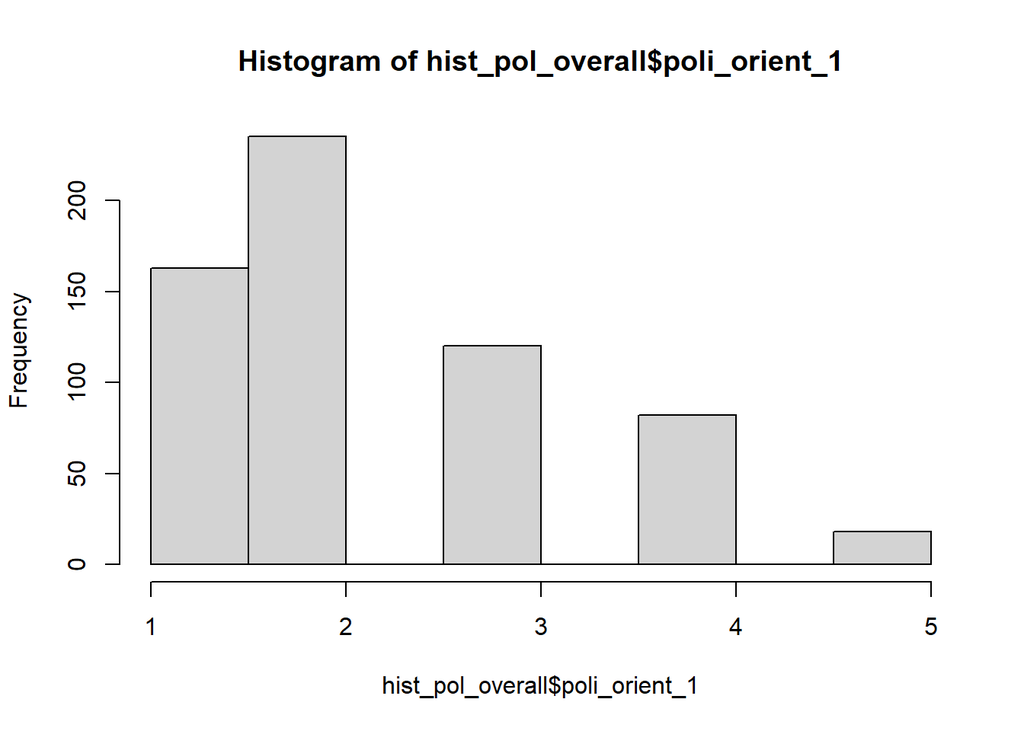

```r
hist_pol_overall <- clean_ptcheck %>%
  select(sub_id, poli_orient_1) %>%
  unique()

hist(hist_pol_overall$poli_orient_1)
```

### In-group:

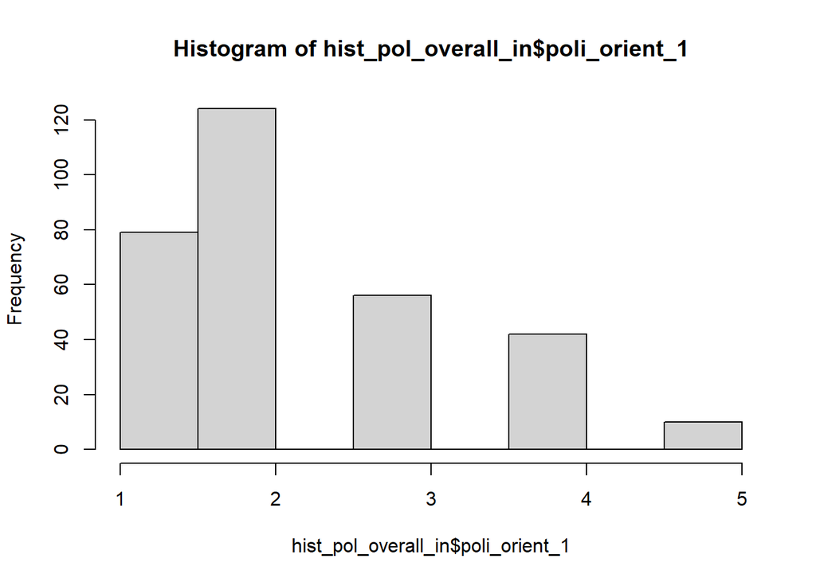

```r
hist_pol_overall_in <- clean_ptcheck %>%
  filter(group_cond == "In-group") %>%
  select(sub_id, poli_orient_1) %>%
  unique()

hist(hist_pol_overall_in$poli_orient_1)
```

### Out-group:

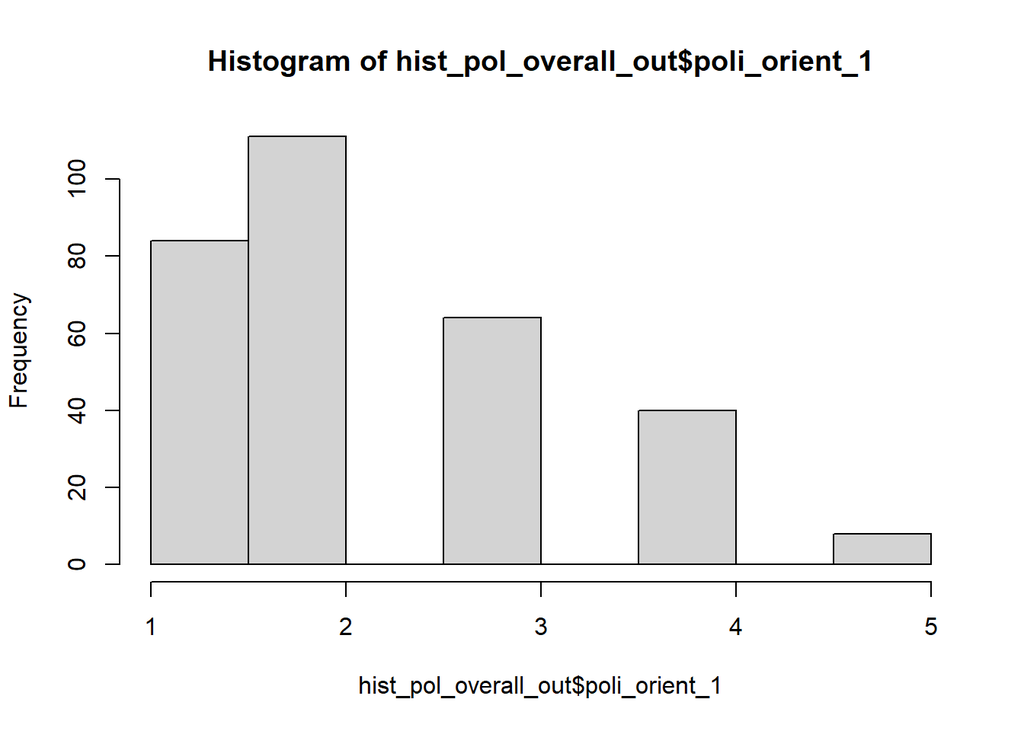

```r
hist_pol_overall_out <- clean_ptcheck %>%
  filter(group_cond == "Out-group") %>%
  select(sub_id, poli_orient_1) %>%
  unique()

hist(hist_pol_overall_out$poli_orient_1)
```

### Trump supporters:

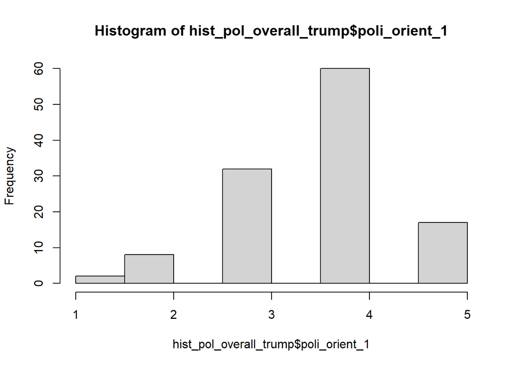

```r
hist_pol_overall_trump <- clean_ptcheck %>%
  filter(opin_pol_combined == "Trump supporter") %>%
  select(sub_id, poli_orient_1) %>%
  unique()

hist(hist_pol_overall_trump$poli_orient_1)
```

### Anti Trump supporters:

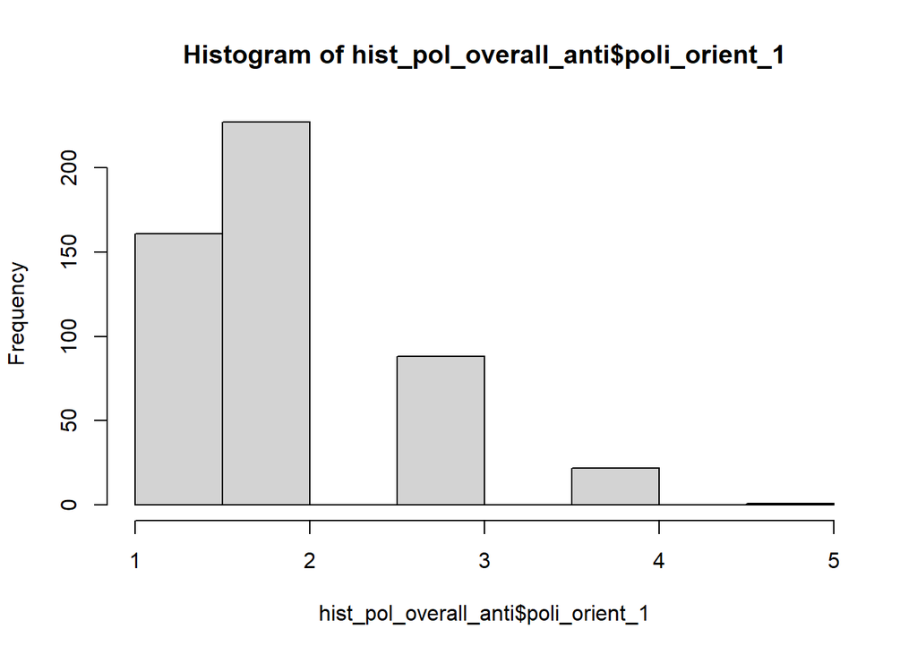

```r
hist_pol_overall_anti <- clean_ptcheck %>%
  filter(opin_pol_combined == "Anti Trump") %>%
  select(sub_id, poli_orient_1) %>%
  unique()

hist(hist_pol_overall_anti$poli_orient_1)
```

## Social political beliefs

Question: *In terms of social and cultural issues (e.g., abortion, separation of church and state, affirmative action), where would you place yourself on the following scale? 1 indicates “Very liberal” and 5 indicates “Very conservative”*

### Across group:

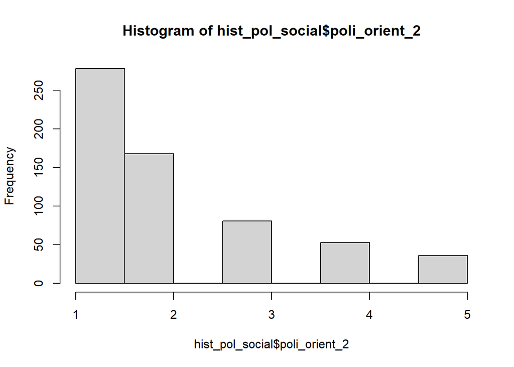

```r
hist_pol_social <- clean_ptcheck %>%
  select(sub_id, poli_orient_2) %>%
  unique()

hist(hist_pol_social$poli_orient_2)
```

### In-group:

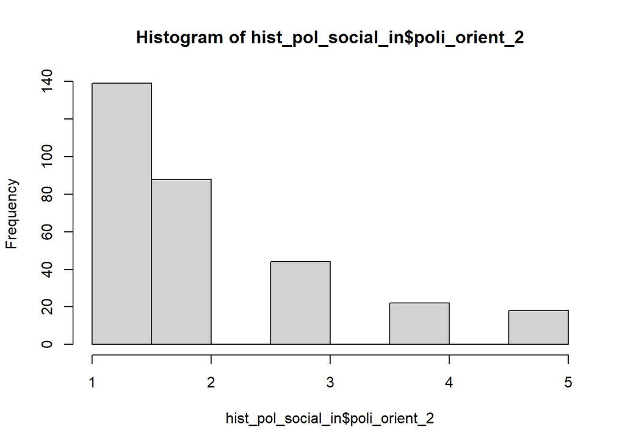

```r
hist_pol_social_in <- clean_ptcheck %>%
  filter(group_cond == "In-group") %>%
  select(sub_id, poli_orient_2) %>%
  unique()

hist(hist_pol_social_in$poli_orient_2)
```

### Out-group:

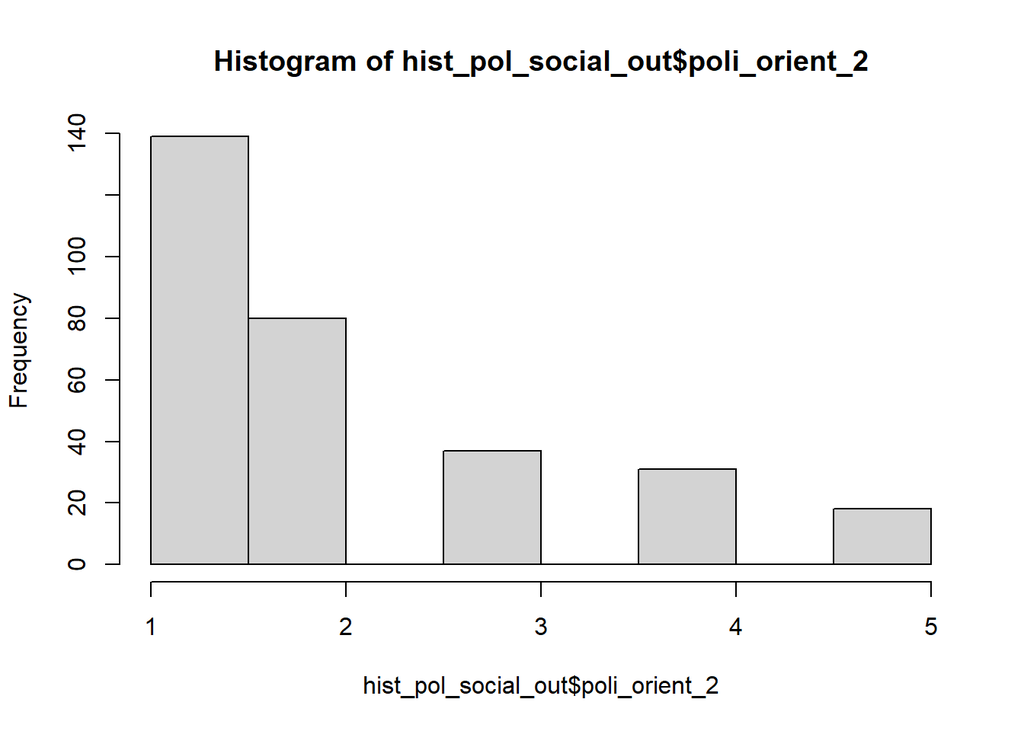

```r
hist_pol_social_out <- clean_ptcheck %>%
  filter(group_cond == "Out-group") %>%
  select(sub_id, poli_orient_2) %>%
  unique()

hist(hist_pol_social_out$poli_orient_2)
```

### Trump supporters:

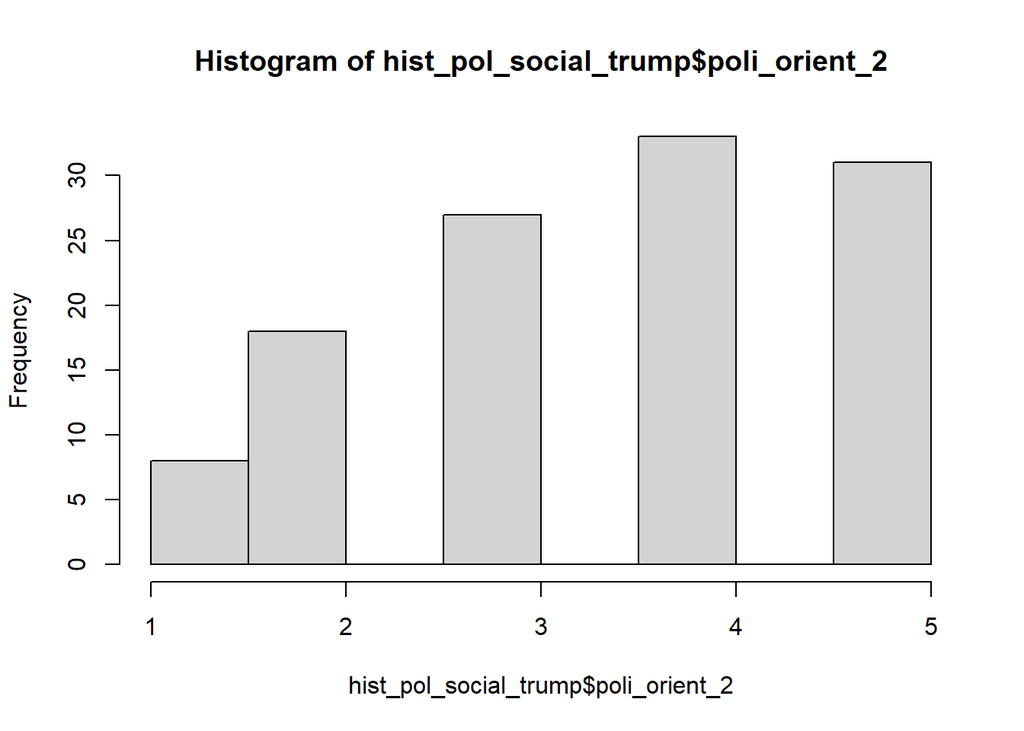

```r
hist_pol_social_trump <- clean_ptcheck %>%
  filter(opin_pol_combined == "Trump supporter") %>%
  select(sub_id, poli_orient_2) %>%
  unique()

hist(hist_pol_social_trump$poli_orient_2)
```

### Anti Trump supporters:

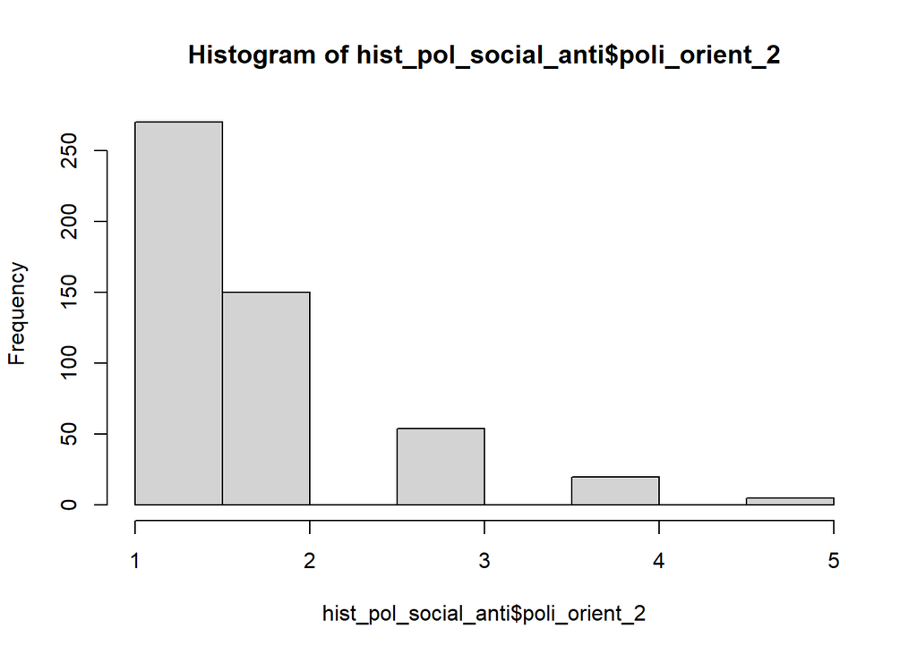

```r
hist_pol_social_anti <- clean_ptcheck %>%
  filter(opin_pol_combined == "Anti Trump") %>%
  select(sub_id, poli_orient_2) %>%
  unique()

hist(hist_pol_social_anti$poli_orient_2)
```

## Economic political beliefs

Question: *In terms of economic issues (e.g., taxation, welfare, privatization of social security), where would you place yourself on the following scale? 1 indicates “Very liberal” and 5 indicates “Very conservative”*

### Across group:

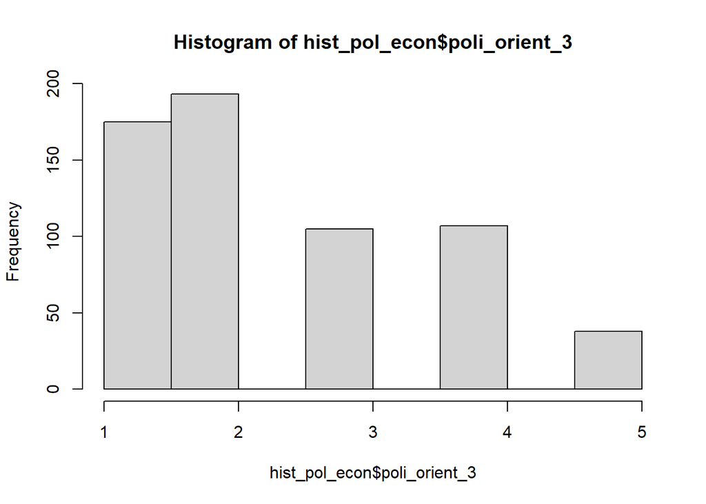

```r
hist_pol_econ <- clean_ptcheck %>%
  select(sub_id, poli_orient_3) %>%
  unique()

hist(hist_pol_econ$poli_orient_3)
```

### In-group:

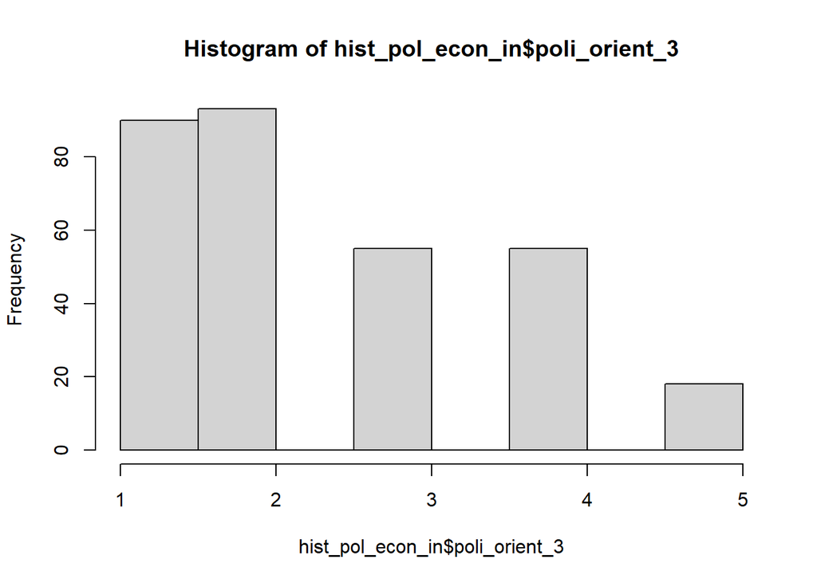

```r
hist_pol_econ_in <- clean_ptcheck %>%
  filter(group_cond == "In-group") %>%
  select(sub_id, poli_orient_3) %>%
  unique()

hist(hist_pol_econ_in$poli_orient_3)
```

### Out-group:

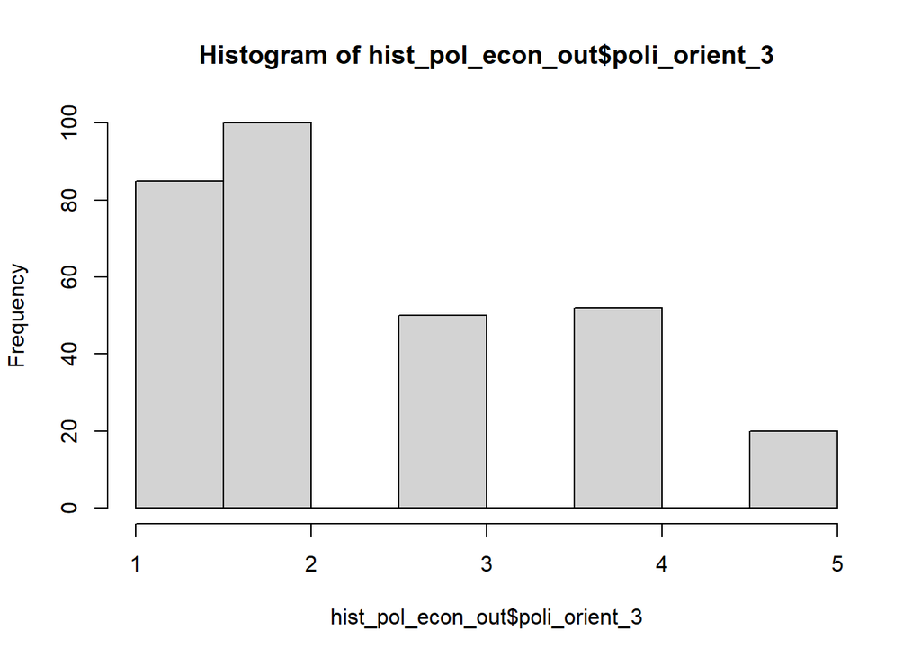

```r
hist_pol_econ_out <- clean_ptcheck %>%
  filter(group_cond == "Out-group") %>%
  select(sub_id, poli_orient_3) %>%
  unique()

hist(hist_pol_econ_out$poli_orient_3)
```

### Trump supporters:

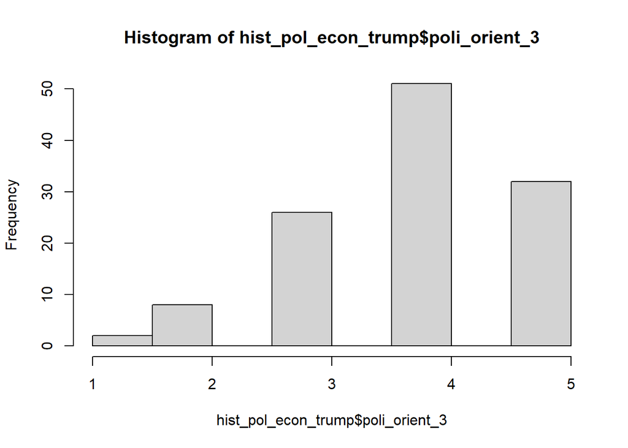

```r
hist_pol_econ_trump <- clean_ptcheck %>%
  filter(opin_pol_combined == "Trump supporter") %>%
  select(sub_id, poli_orient_3) %>%
  unique()

hist(hist_pol_econ_trump$poli_orient_3)
```

### Anti Trump supporters:

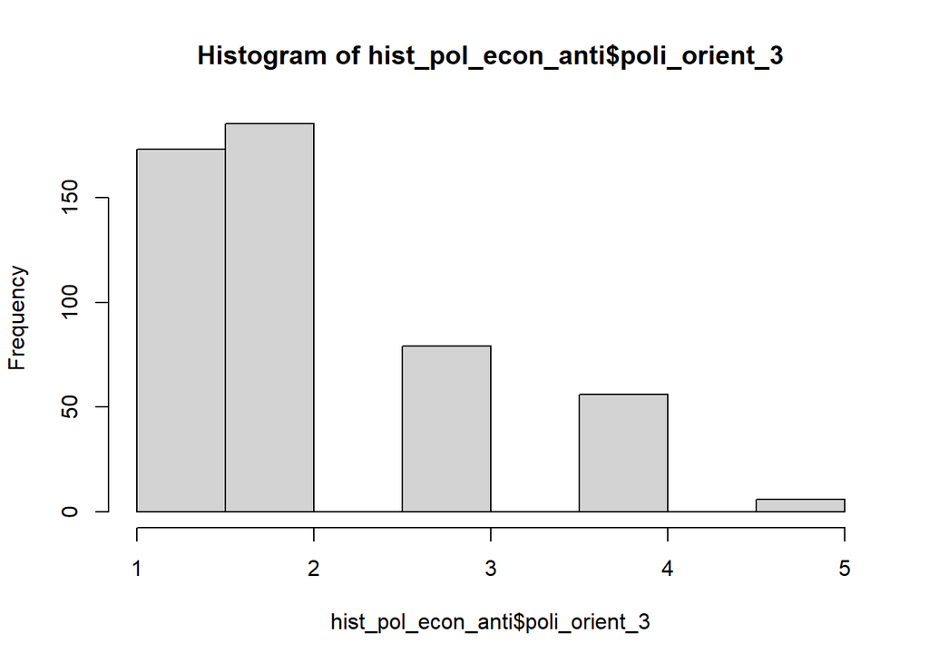

```r
hist_pol_econ_anti <- clean_ptcheck %>%
  filter(opin_pol_combined == "Anti Trump") %>%
  select(sub_id, poli_orient_3) %>%
  unique()

hist(hist_pol_econ_anti$poli_orient_3)
```

## Political knowledge

Question: *Which party has the most members in the U.S. House of Representatives in Washington, D.C.?*

**This data was collected in October 2020, when the House was Democratic**

```r
clean_ptcheck %>%
  select(sub_id, house_most_members) %>%
  na.omit() %>%
  unique() %>%
  mutate(house_most_members = dplyr::recode(house_most_members,
                                            `2` = "Democrat control",
                                            `6` = "Republican control",
                                            `3` = "Do not know")) %>%
  group_by(house_most_members) %>%
  count()
```

```
## # A tibble: 3 x 2
## # Groups:   house_most_members [3]
##   house_most_members     n
##   <chr>              <int>
## 1 Democrat control     389
## 2 Do not know          104
## 3 Republican control   114
```

This question shows that 114 people answered incorrectly and 104 did not know. Political knowledge and extreme political beliefs (how liberal or conservative someone is) could impact results and could be used as an exploratory moderator.

## Scale Validity

### BFI

#### Extraversion

```r
BFI_valid <- clean_ptcheck %>%
  select(sub_id, selfBFI, BFI_number) %>%
  unique() %>%
  pivot_wider(names_from = BFI_number, values_from = selfBFI)

extraversion <- BFI_valid %>%
  select(c("1", "6", "11"))
psych::alpha(extraversion)
```

```
##
## Reliability analysis
## Call: psych::alpha(x = extraversion)
##
##   raw_alpha std.alpha G6(smc) average_r S/N   ase mean   sd median_r
##       0.58      0.58    0.49      0.32 1.4 0.029  2.6 0.88     0.27
##
##  lower alpha upper     95% confidence boundaries
## 0.53 0.58 0.64
##
##  Reliability if an item is dropped:
##    raw_alpha std.alpha G6(smc) average_r  S/N alpha se var.r med.r
## 1       0.42      0.42    0.27      0.27 0.73    0.046    NA  0.27
## 6       0.42      0.42    0.27      0.27 0.72    0.047    NA  0.27
## 11      0.59      0.59    0.42      0.42 1.45    0.033    NA  0.42
##
##  Item statistics
##      n raw.r std.r r.cor r.drop mean  sd
## 1  614  0.78  0.76  0.57   0.43  2.3 1.2
## 6  615  0.77  0.76  0.57   0.44  2.7 1.2
## 11 616  0.68  0.69  0.41   0.32  2.9 1.1
##
## Non missing response frequency for each item
##       1    2    3    4    5 miss
## 1  0.32 0.32 0.15 0.14 0.06 0.01
## 6  0.19 0.25 0.27 0.23 0.07 0.00
## 11 0.12 0.27 0.31 0.22 0.08 0.00
```

#### Agreeablesness

```r
agreeable <- BFI_valid %>%
  select(c("2", "7", "12"))
psych::alpha(agreeable)
```

```
##
## Reliability analysis
## Call: psych::alpha(x = agreeable)
##
##   raw_alpha std.alpha G6(smc) average_r S/N   ase mean  sd median_r
##       0.54      0.56    0.47      0.29 1.3 0.032  3.6 0.8     0.25
##
##  lower alpha upper     95% confidence boundaries
## 0.48 0.54 0.6
##
##  Reliability if an item is dropped:
##    raw_alpha std.alpha G6(smc) average_r  S/N alpha se var.r med.r
## 2       0.37      0.37    0.22      0.22 0.58    0.051    NA  0.22
## 7       0.57      0.58    0.41      0.41 1.39    0.033    NA  0.41
## 12      0.39      0.40    0.25      0.25 0.67    0.047    NA  0.25
##
##  Item statistics
##      n raw.r std.r r.cor r.drop mean   sd
## 2  616  0.71  0.76  0.57   0.42  4.1 0.92
## 7  615  0.72  0.68  0.37   0.28  3.5 1.23
## 12 617  0.75  0.75  0.55   0.38  3.3 1.15
##
## Non missing response frequency for each item
##       1    2    3    4    5 miss
## 2  0.01 0.06 0.13 0.40 0.40    0
## 7  0.04 0.21 0.20 0.25 0.29    0
## 12 0.08 0.18 0.25 0.35 0.14    0
```

#### Conscientiousness

```r
conscientious <- BFI_valid %>%
  select(c("3", "8", "13"))
psych::alpha(conscientious)
```

```
##
## Reliability analysis
## Call: psych::alpha(x = conscientious)
##
##   raw_alpha std.alpha G6(smc) average_r S/N   ase mean   sd median_r
##       0.63      0.63    0.54      0.36 1.7 0.025  3.3 0.91      0.3
##
##  lower alpha upper     95% confidence boundaries
## 0.58 0.63 0.68
##
##  Reliability if an item is dropped:
##    raw_alpha std.alpha G6(smc) average_r  S/N alpha se var.r med.r
## 3       0.43      0.44    0.28      0.28 0.78    0.045    NA  0.28
## 8       0.44      0.46    0.30      0.30 0.85    0.043    NA  0.30
## 13      0.66      0.66    0.50      0.50 1.98    0.027    NA  0.50
##
##  Item statistics
##      n raw.r std.r r.cor r.drop mean   sd
## 3  618  0.82  0.79  0.64   0.51  3.2 1.31
## 8  616  0.81  0.78  0.62   0.50  2.7 1.29
## 13 615  0.64  0.70  0.41   0.33  4.0 0.99
##
## Non missing response frequency for each item
##       1    2    3    4    5 miss
## 3  0.12 0.24 0.18 0.27 0.19    0
## 8  0.19 0.35 0.16 0.19 0.11    0
## 13 0.01 0.09 0.17 0.39 0.34    0
```

#### Negative Emotionality

```r
neg_emo <- BFI_valid %>%
  select(c("4", "9", "14"))
psych::alpha(neg_emo)
```

```
##
## Reliability analysis
## Call: psych::alpha(x = neg_emo)
##
##   raw_alpha std.alpha G6(smc) average_r S/N   ase mean  sd median_r
##        0.8       0.8    0.72      0.57 3.9 0.014  3.2 1.1     0.57
##
##  lower alpha upper     95% confidence boundaries
## 0.77 0.8 0.82
##
##  Reliability if an item is dropped:
##    raw_alpha std.alpha G6(smc) average_r S/N alpha se var.r med.r
## 4       0.72      0.72    0.57      0.57 2.6    0.022    NA  0.57
## 9       0.70      0.70    0.54      0.54 2.3    0.024    NA  0.54
## 14      0.75      0.75    0.59      0.59 2.9    0.020    NA  0.59
##
##  Item statistics
##      n raw.r std.r r.cor r.drop mean  sd
## 4  616  0.84  0.84  0.72   0.64  3.7 1.3
## 9  618  0.86  0.85  0.74   0.66  3.1 1.3
## 14 613  0.83  0.83  0.69   0.62  2.8 1.2
##
## Non missing response frequency for each item
##       1    2    3    4    5 miss
## 4  0.08 0.14 0.15 0.30 0.33 0.00
## 9  0.16 0.21 0.16 0.30 0.17 0.00
## 14 0.18 0.27 0.25 0.21 0.09 0.01
```

#### Open mindedness

```r
open_minded <- BFI_valid %>%
  select(c("5", "10", "15"))
psych::alpha(open_minded)
```

```
##
## Reliability analysis
## Call: psych::alpha(x = open_minded)
##
##   raw_alpha std.alpha G6(smc) average_r S/N   ase mean   sd median_r
##       0.62      0.62    0.53      0.36 1.7 0.026  3.8 0.81     0.36
##
##  lower alpha upper     95% confidence boundaries
## 0.57 0.62 0.68
##
##  Reliability if an item is dropped:
##    raw_alpha std.alpha G6(smc) average_r S/N alpha se var.r med.r
## 5       0.55      0.55    0.38      0.38 1.2    0.037    NA  0.38
## 10      0.50      0.50    0.33      0.33 1.0    0.040    NA  0.33
## 15      0.53      0.53    0.36      0.36 1.1    0.038    NA  0.36
##
##  Item statistics
##      n raw.r std.r r.cor r.drop mean  sd
## 5  616  0.75  0.75  0.53   0.42  4.0 1.1
## 10 613  0.77  0.77  0.57   0.45  3.8 1.1
## 15 616  0.75  0.75  0.54   0.43  3.6 1.0
##
## Non missing response frequency for each item
##       1    2    3    4    5 miss
## 5  0.02 0.09 0.15 0.33 0.41 0.00
## 10 0.03 0.10 0.20 0.34 0.33 0.01
## 15 0.02 0.16 0.20 0.42 0.20 0.00
```

#### Honesty/morality

```r
honest_moral <- BFI_valid %>%
  select(c("16", "17", "18", "19"))
psych::alpha(honest_moral)
```

```
##
## Reliability analysis
## Call: psych::alpha(x = honest_moral)
##
##   raw_alpha std.alpha G6(smc) average_r S/N   ase mean   sd median_r
##       0.53      0.54    0.49      0.23 1.2 0.031  3.6 0.71     0.24
##
##  lower alpha upper     95% confidence boundaries
## 0.47 0.53 0.59
##
##  Reliability if an item is dropped:
##    raw_alpha std.alpha G6(smc) average_r  S/N alpha se  var.r med.r
## 16      0.50      0.49    0.41      0.25 0.98    0.035 0.0128  0.24
## 17      0.44      0.44    0.35      0.21 0.79    0.038 0.0043  0.23
## 18      0.48      0.50    0.41      0.25 0.98    0.037 0.0145  0.26
## 19      0.42      0.43    0.34      0.20 0.74    0.041 0.0046  0.23
##
##  Item statistics
##      n raw.r std.r r.cor r.drop mean   sd
## 16 616  0.66  0.62  0.40   0.28  3.2 1.24
## 17 618  0.66  0.67  0.49   0.34  3.5 1.14
## 18 615  0.61  0.62  0.39   0.30  4.1 1.03
## 19 614  0.65  0.68  0.52   0.37  3.6 0.99
##
## Non missing response frequency for each item
##       1    2    3    4    5 miss
## 16 0.10 0.20 0.24 0.29 0.18 0.00
## 17 0.03 0.21 0.21 0.33 0.22 0.00
## 18 0.01 0.09 0.13 0.30 0.46 0.00
## 19 0.03 0.11 0.24 0.45 0.17 0.01
```

### ED scale

#### Correlation matrix

```r
ED_alpha <- clean_ptcheck %>%
  select(sub_id, selfED, ED_number) %>%
  unique() %>%
  pivot_wider(names_from = ED_number, values_from = selfED) %>%
  select(-sub_id) %>%
  na.omit()

cor(ED_alpha)
```

```
##             1          2           3           4           5
## 1  1.00000000  0.1199463 -0.12896094  0.06624321  0.03050594
## 2  0.11994628  1.0000000 -0.03861550  0.03685120  0.12259265
## 3 -0.12896094 -0.0386155  1.00000000 -0.04257039 -0.03760632
## 4  0.06624321  0.0368512 -0.04257039  1.00000000  0.08028207
## 5  0.03050594  0.1225926 -0.03760632  0.08028207  1.00000000
```

#### Alpha

```r
psych::alpha(ED_alpha, check.keys=TRUE)
```

```
##
## Reliability analysis
## Call: psych::alpha(x = ED_alpha, check.keys = TRUE)
##
##   raw_alpha std.alpha G6(smc) average_r  S/N   ase mean   sd median_r
##       0.26      0.27    0.24      0.07 0.38 0.047  3.4 0.61    0.054
##
##  lower alpha upper     95% confidence boundaries
## 0.16 0.26 0.35
##
##  Reliability if an item is dropped:
##    raw_alpha std.alpha G6(smc) average_r  S/N alpha se  var.r med.r
## 1       0.18      0.20    0.16     0.060 0.25    0.053 0.0012 0.041
## 2       0.21      0.22    0.17     0.064 0.28    0.051 0.0014 0.054
## 3-      0.23      0.25    0.20     0.076 0.33    0.050 0.0016 0.073
## 4       0.25      0.26    0.21     0.080 0.35    0.049 0.0024 0.079
## 5       0.22      0.24    0.19     0.072 0.31    0.051 0.0018 0.054
##
##  Item statistics
##      n raw.r std.r r.cor r.drop mean  sd
## 1  613  0.48  0.53  0.31  0.161  3.7 1.0
## 2  613  0.45  0.52  0.28  0.130  4.0 1.0
## 3- 613  0.57  0.49  0.22  0.108  3.2 1.4
## 4  613  0.57  0.48  0.19  0.098  3.0 1.5
## 5  613  0.44  0.50  0.24  0.119  3.3 1.0
##
## Non missing response frequency for each item
##      1    2    3    4    5 miss
## 1 0.04 0.08 0.24 0.41 0.23    0
## 2 0.04 0.06 0.10 0.46 0.35    0
## 3 0.26 0.19 0.19 0.19 0.17    0
## 4 0.21 0.24 0.09 0.26 0.20    0
## 5 0.05 0.16 0.38 0.31 0.10    0
```

This is the alpha for the entire scale. We also conduct a factor analysis later and look at alphas for those latent factors below.

# Pre-reg Mod 1: Projection by group w/ BFI

## Model

```r
# removing na's and repeat data due to long-format variables no longer included in this analysis
model1_data <- clean_ptcheck %>%
  select(sub_id, BFI_number, BFI_target_group, TargBFI, selfBFI_c, group_cond,
         opin_pol_combined) %>%
  # changing the name in the model data-set so the function below will work the same for all models
  mutate(self_c = selfBFI_c) %>%
  na.omit() %>%
  unique()
```

### Effects coding contrasts

```r
contrasts(model1_data$group_cond) <- contr.sum(2)
contrasts(model1_data$group_cond)
```

```
##           [,1]
## In-group     1
## Out-group   -1
```

### Results

```r
model1 <- lmer(TargBFI ~ self_c*group_cond + (self_c|sub_id),
               data = model1_data)
summary(model1)
```

```
## Linear mixed model fit by REML. t-tests use Satterthwaite's method [
## lmerModLmerTest]
## Formula: TargBFI ~ self_c * group_cond + (self_c | sub_id)
##    Data: model1_data
##
## REML criterion at convergence: 34797.7
##
## Scaled residuals:
##     Min      1Q  Median      3Q     Max
## -3.3636 -0.6016  0.0513  0.6690  2.9931
##
## Random effects:
##  Groups   Name        Variance Std.Dev. Corr
##  sub_id   (Intercept) 0.11345  0.3368
##           self_c      0.06369  0.2524   0.42
##  Residual             1.02718  1.0135
## Number of obs: 11697, groups:  sub_id, 618
##
## Fixed effects:
##                     Estimate Std. Error        df t value             Pr(>|t|)
## (Intercept)          3.33557    0.01662 615.49804  200.73 < 0.0000000000000002
## self_c               0.08403    0.01287 623.47711    6.53       0.000000000137
## group_cond1          0.26445    0.01662 615.49804   15.91 < 0.0000000000000002
## self_c:group_cond1   0.13490    0.01287 623.47711   10.48 < 0.0000000000000002
##
## (Intercept)        ***
## self_c             ***
## group_cond1        ***
## self_c:group_cond1 ***
## ---
## Signif. codes:  0 '***' 0.001 '**' 0.01 '*' 0.05 '.' 0.1 ' ' 1
##
## Correlation of Fixed Effects:
##             (Intr) self_c grp_c1
## self_c       0.275
## group_cond1 -0.004  0.004
## slf_c:grp_1  0.004 -0.005  0.275
```

```r
confint(model1)
```

```
##                         2.5 %    97.5 %
## .sig01             0.30854577 0.3652511
## .sig02             0.30989418 0.5256840
## .sig03             0.23035476 0.2744961
## .sigma             0.99994024 1.0273572
## (Intercept)        3.30301018 3.3681434
## self_c             0.05879765 0.1092700
## group_cond1        0.23189840 0.2970657
## self_c:group_cond1 0.10965877 0.1601214
```

## Plot

```r
##### Function to obtain and clean data from model & run base plot for ME group on projection #####
get_groupME_proj_plot <- function(x){
  effects_data <- effect(term = "self_c:group_cond",
         xlevels = list(group_cond = c("In-group", "Out-group")),
         mod = x)

  effects_data <- as.data.frame(effects_data)

  groupME_plot <- ggplot(effects_data, aes(self_c, fit, group = group_cond)) +
  geom_smooth(method = "lm",
              se = FALSE,
              size = .7,
              colour = "black",
              aes(linetype = group_cond)) +
  theme_minimal(base_size = 13) +
  theme(legend.key.size = unit(1, "cm"))

  return(groupME_plot)
}
```

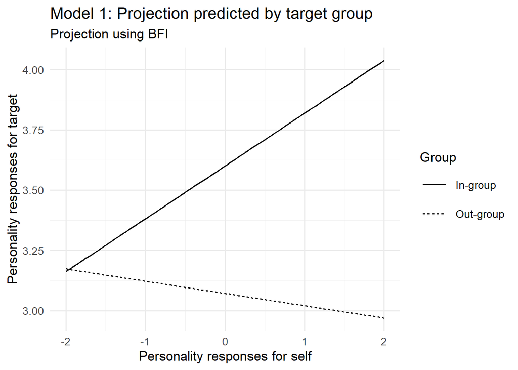

```r
# Function to print plots to pngs for paper
# ggpreview <- function(...) {
#   fname <- tempfile(fileext = ".png")
#   ggsave(filename = fname, ...)
#   system2("open", fname)
#   invisible(NULL)
# }

knitr::opts_chunk$set(fig.width = 8, fig.height = 6)

model1_plot <- get_groupME_proj_plot(model1)

model1_plot +
  labs(title = "Model 1: Projection predicted by target group",
       subtitle = "Projection using BFI",
       x = "Personality responses for self",
       y = "Personality responses for target",
       linetype = "Group")
```

```r
# ggpreview(width = 8, height = 6, units = "in")

#Murat's alternative in interact plot if I want to use it in the future
#interactions::interact_plot(model1, pred = "self_c", modx = "group_cond", plot.points = F, interval = F)
```

We replicate our prior finding that people counter project with their political out-group, but project positively with their political in-group target.

This supports Confirmatory Prediction #1: *“People will counter-project to a target person from their political out-group and project to a target person from their in-group.”*

# Hierarchical build-up to Pre-reg Mod 2

```r
model2ED_data <- clean_ptcheck %>%
  select(sub_id, ED_number, TargED, selfED_c, group_cond,
         opin_pol_combined, stereoED_c) %>%
  # renaming for group ME function
  mutate(self_c = selfED_c) %>%
  na.omit() %>%
  unique()
```

### Effects codes applied to all data-sets

```r
contrasts(model2ED_data$group_cond) <- contr.sum(2)
contrasts(model2ED_data$group_cond)
```

```
##           [,1]
## In-group     1
## Out-group   -1
```

## Everyday Likes (ED) w/o stereo model

### Results

```r
model2ED_nostereo <- lmer(TargED ~ self_c*group_cond + (self_c|sub_id),
               data = model2ED_data)
summary(model2ED_nostereo)
```

```
## Linear mixed model fit by REML. t-tests use Satterthwaite's method [
## lmerModLmerTest]
## Formula: TargED ~ self_c * group_cond + (self_c | sub_id)
##    Data: model2ED_data
##
## REML criterion at convergence: 9067.5
##
## Scaled residuals:
##     Min      1Q  Median      3Q     Max
## -2.6508 -0.4794  0.1274  0.6645  2.5192
##
## Random effects:
##  Groups   Name        Variance Std.Dev. Corr
##  sub_id   (Intercept) 0.02905  0.1705
##           self_c      0.06734  0.2595   0.81
##  Residual             0.99345  0.9967
## Number of obs: 3079, groups:  sub_id, 618
##
## Fixed effects:
##                     Estimate Std. Error        df t value             Pr(>|t|)
## (Intercept)          3.34608    0.01978 619.40563 169.207 < 0.0000000000000002
## self_c              -0.01829    0.01789 550.30099  -1.023                0.307
## group_cond1          0.09489    0.01978 619.40563   4.798       0.000002006690
## self_c:group_cond1   0.11324    0.01789 550.30099   6.332       0.000000000504
##
## (Intercept)        ***
## self_c
## group_cond1        ***
## self_c:group_cond1 ***
## ---
## Signif. codes:  0 '***' 0.001 '**' 0.01 '*' 0.05 '.' 0.1 ' ' 1
##
## Correlation of Fixed Effects:
##             (Intr) self_c grp_c1
## self_c       0.169
## group_cond1 -0.005  0.019
## slf_c:grp_1  0.019  0.008  0.169
```

```r
confint(model2ED_nostereo)
```

```
##                          2.5 %     97.5 %
## .sig01              0.09018193 0.24283694
## .sig02              0.42492914 0.96409936
## .sig03              0.21534459 0.30043719
## .sigma              0.96669158 1.02782710
## (Intercept)         3.30733352 3.38483691
## self_c             -0.05331261 0.01682046
## group_cond1         0.05611901 0.13362174
## self_c:group_cond1  0.07815251 0.14828700
```

### Plots

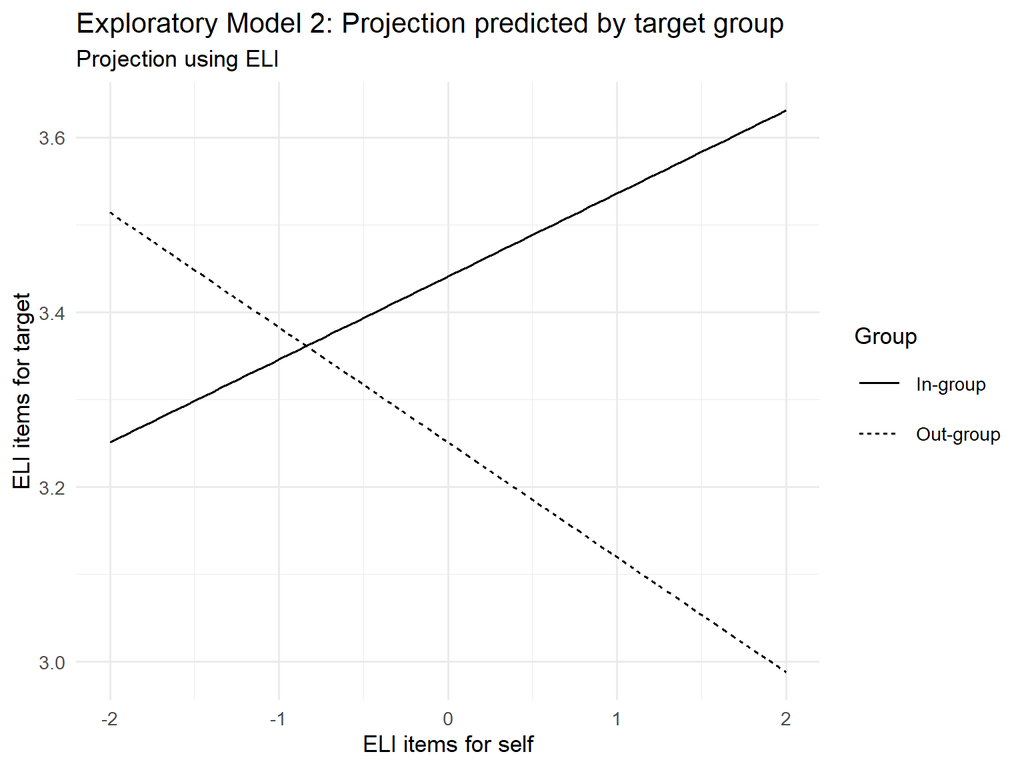

```r
knitr::opts_chunk$set(fig.width = 8, fig.height = 6)

model2group_plot_EDnostereo <- get_groupME_proj_plot(model2ED_nostereo)

model2group_plot_EDnostereo +
  labs(title = "Exploratory Model 2: Projection predicted by target group",
       subtitle = "Projection using ELI",
       x = "ELI items for self",
       y = "ELI items for target",
       linetype = "Group")
```

```r
# ggpreview(width = 8, height = 6, units = "in")
```

Without stereotyping, we see even more extreme counter projection.

## ED w/ stereo model

### Results

```r
model2EDwstereo <- lmer(TargED ~ self_c*group_cond*stereoED_c + (1|sub_id),
               data = model2ED_data)
summary(model2EDwstereo)
```

```
## Linear mixed model fit by REML. t-tests use Satterthwaite's method [
## lmerModLmerTest]
## Formula: TargED ~ self_c * group_cond * stereoED_c + (1 | sub_id)
##    Data: model2ED_data
##
## REML criterion at convergence: 8421.7
##
## Scaled residuals:
##     Min      1Q  Median      3Q     Max
## -3.5980 -0.5031  0.0016  0.7208  3.2985
##
## Random effects:
##  Groups   Name        Variance Std.Dev.
##  sub_id   (Intercept) 0.02427  0.1558
##  Residual             0.86646  0.9308
## Number of obs: 3079, groups:  sub_id, 618
##
## Fixed effects:
##                                  Estimate  Std. Error          df t value
## (Intercept)                      3.348292    0.018294  645.821251 183.030
## self_c                          -0.049046    0.013474 3050.428326  -3.640
## group_cond1                      0.037427    0.018294  645.821251   2.046
## stereoED_c                       0.482390    0.017821 3068.694113  27.069
## self_c:group_cond1               0.063855    0.013474 3050.428326   4.739
## self_c:stereoED_c                0.016300    0.012573 3025.626019   1.296
## group_cond1:stereoED_c          -0.040099    0.017821 3068.694113  -2.250
## self_c:group_cond1:stereoED_c    0.002197    0.012573 3025.626019   0.175
##                                           Pr(>|t|)
## (Intercept)                   < 0.0000000000000002 ***
## self_c                                    0.000277 ***
## group_cond1                               0.041172 *
## stereoED_c                    < 0.0000000000000002 ***
## self_c:group_cond1                      0.00000225 ***
## self_c:stereoED_c                         0.194912
## group_cond1:stereoED_c                    0.024513 *
## self_c:group_cond1:stereoED_c             0.861313
## ---
## Signif. codes:  0 '***' 0.001 '**' 0.01 '*' 0.05 '.' 0.1 ' ' 1
##
## Correlation of Fixed Effects:
##             (Intr) self_c grp_c1 strED_ sl_:_1 s_:ED_ g_1:ED
## self_c       0.031
## group_cond1  0.023  0.046
## stereoED_c  -0.045 -0.137 -0.117
## slf_c:grp_1  0.046  0.051  0.031 -0.185
## slf_c:stED_ -0.106 -0.027 -0.154  0.040 -0.053
## grp_cn1:ED_ -0.117 -0.185 -0.045  0.302 -0.137  0.030
## slf_:_1:ED_ -0.154 -0.053 -0.106  0.030 -0.027  0.227  0.040
```

```r
confint(model2EDwstereo)
```

```
##                                      2.5 %       97.5 %
## .sig01                         0.015746587  0.221856725
## .sigma                         0.904513264  0.956574391
## (Intercept)                    3.312481361  3.384115577
## self_c                        -0.075425410 -0.022595462
## group_cond1                    0.001618700  0.073258426
## stereoED_c                     0.447489129  0.517278233
## self_c:group_cond1             0.037469395  0.090238312
## self_c:stereoED_c             -0.008419201  0.041156281
## group_cond1:stereoED_c        -0.075019201 -0.005216825
## self_c:group_cond1:stereoED_c -0.022414388  0.026820123
```

Running Everyday Likes on its own with stereotyping (Model 2 pre-registered adding both ED and stereotyping at once) does not converge. Most likely due to too few items nested within the higher level for so many variables and not enough variance between the two.

We removed random slopes for the selfED_c predictor and then the model converged. To see if that patterns observed in this fixed effects model are reliable, we looked at the impact of removing random slopes for self in models for the everyday likes without stereotyping and BFI with stereotyping and found it did not have an impact on results, making us trust the patterns shown in this model.

### Plots

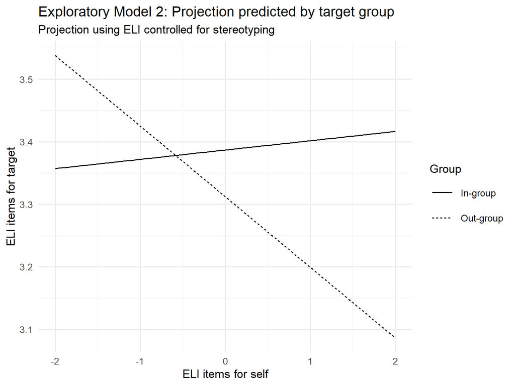

```r
knitr::opts_chunk$set(fig.width = 8, fig.height = 6)

model2group_plot_EDwstereo <- get_groupME_proj_plot(model2EDwstereo)

model2group_plot_EDwstereo +
  labs(title = "Exploratory Model 2: Projection predicted by target group",
       subtitle = "Projection using ELI controlled for stereotyping",
       x = "ELI items for self",
       y = "ELI items for target",
       linetype = "Group")
```

```r
# ggpreview(width = 8, height = 6, units = "in")
```

We still see counter projection, even when controlling for stereotyping.

## ED no cats/dogs

```r
mod2_ED_nodogs <- clean_ptcheck %>%
  select(sub_id, ED_number, TargED, selfED_c, group_cond,
         opin_pol_combined, stereoED_c) %>%
  # renaming for group ME function
  mutate(self_c = selfED_c) %>%
  filter(ED_number != "3") %>%
  na.omit() %>%
  unique()
```

### Results without stereotyping

```r
model2ED_nodogsORstereo <- lmer(TargED ~ self_c*group_cond + (self_c|sub_id),
               data = mod2_ED_nodogs)
summary(model2ED_nodogsORstereo)
```

```
## Linear mixed model fit by REML. t-tests use Satterthwaite's method [
## lmerModLmerTest]
## Formula: TargED ~ self_c * group_cond + (self_c | sub_id)
##    Data: mod2_ED_nodogs
##
## REML criterion at convergence: 6827.2
##
## Scaled residuals:
##     Min      1Q  Median      3Q     Max
## -3.1085 -0.5359  0.1999  0.5771  2.3303
##
## Random effects:
##  Groups   Name        Variance Std.Dev. Corr
##  sub_id   (Intercept) 0.14911  0.3861
##           self_c      0.04156  0.2039   0.42
##  Residual             0.75619  0.8696
## Number of obs: 2462, groups:  sub_id, 618
##
## Fixed effects:
##                             Estimate Std. Error        df t value
## (Intercept)                  3.55804    0.03368 603.69180 105.641
## self_c                       0.06034    0.02544 553.82676   2.372
## group_condOut-group         -0.17155    0.04788 606.39201  -3.583
## self_c:group_condOut-group  -0.21383    0.03569 536.16060  -5.992
##                                        Pr(>|t|)
## (Intercept)                < 0.0000000000000002 ***
## self_c                                 0.018036 *
## group_condOut-group                    0.000367 ***
## self_c:group_condOut-group         0.0000000038 ***
## ---
## Signif. codes:  0 '***' 0.001 '**' 0.01 '*' 0.05 '.' 0.1 ' ' 1
##
## Correlation of Fixed Effects:
##             (Intr) self_c grp_O-
## self_c       0.068
## grp_cndOt-g -0.703 -0.048
## slf_c:gr_O- -0.049 -0.713  0.049
```

```r
confint(model2ED_nodogsORstereo)
```

```
##                                  2.5 %      97.5 %
## .sig01                      0.32990545  0.43858726
## .sig02                      0.17902682  0.68662752
## .sig03                      0.15025344  0.25021555
## .sigma                      0.83956401  0.90116700
## (Intercept)                 3.49203535  3.62413950
## self_c                      0.01046562  0.11045559
## group_condOut-group        -0.26540238 -0.07775471
## self_c:group_condOut-group -0.28381933 -0.14387152
```

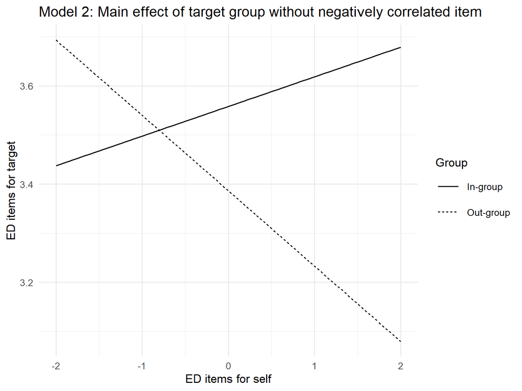

```r
model2group_plot_EDnodogsORstereo <- get_groupME_proj_plot(model2ED_nodogsORstereo)

model2group_plot_EDnodogsORstereo +
  labs(title = "Model 2: Main effect of target group without negatively correlated item",
       x = "ED items for self",
       y = "ED items for target",
       linetype = "Group")
```

Does not impact counter projection results without stereotyping. Though the main effect of projection is now significant but the main effect of target group does not change.

### Results with stereotyping

```r
model2ED_nodogs_wstereo <- lmer(TargED ~ self_c*group_cond*stereoED_c + (self_c|sub_id),
               data = mod2_ED_nodogs)
summary(model2ED_nodogs_wstereo)
```

```
## Linear mixed model fit by REML. t-tests use Satterthwaite's method [
## lmerModLmerTest]
## Formula: TargED ~ self_c * group_cond * stereoED_c + (self_c | sub_id)
##    Data: mod2_ED_nodogs
##
## REML criterion at convergence: 6382.4
##
## Scaled residuals:
##     Min      1Q  Median      3Q     Max
## -3.9677 -0.4585  0.0825  0.5969  3.4986
##
## Random effects:
##  Groups   Name        Variance Std.Dev. Corr
##  sub_id   (Intercept) 0.09480  0.3079
##           self_c      0.02716  0.1648   0.17
##  Residual             0.65395  0.8087
## Number of obs: 2462, groups:  sub_id, 618
##
## Fixed effects:
##                                          Estimate  Std. Error          df
## (Intercept)                              3.474449    0.030602  650.977067
## self_c                                  -0.009131    0.024089  606.842143
## group_condOut-group                     -0.117896    0.042856  628.644085
## stereoED_c                               0.379481    0.032467 2347.879503
## self_c:group_condOut-group              -0.110852    0.033325  576.852434
## self_c:stereoED_c                        0.044489    0.024701 1519.415033
## group_condOut-group:stereoED_c           0.077462    0.040277 2415.668180
## self_c:group_condOut-group:stereoED_c   -0.011968    0.031115 1691.782984
##                                       t value             Pr(>|t|)
## (Intercept)                           113.538 < 0.0000000000000002 ***
## self_c                                 -0.379             0.704761
## group_condOut-group                    -2.751             0.006113 **
## stereoED_c                             11.688 < 0.0000000000000002 ***
## self_c:group_condOut-group             -3.326             0.000936 ***
## self_c:stereoED_c                       1.801             0.071887 .
## group_condOut-group:stereoED_c          1.923             0.054568 .
## self_c:group_condOut-group:stereoED_c  -0.385             0.700546
## ---
## Signif. codes:  0 '***' 0.001 '**' 0.01 '*' 0.05 '.' 0.1 ' ' 1
##
## Correlation of Fixed Effects:
##             (Intr) self_c grp_O- strED_ sl_:_O- s_:ED_ g_O-:E
## self_c       0.058
## grp_cndOt-g -0.714 -0.041
## stereoED_c  -0.201 -0.210  0.144
## slf_c:gr_O- -0.042 -0.723 -0.017  0.152
## slf_c:stED_ -0.170 -0.222  0.122 -0.068  0.161
## grp_cO-:ED_  0.162  0.169 -0.146 -0.806 -0.076   0.055
## sl_:_O-:ED_  0.135  0.177 -0.051  0.054 -0.207  -0.794 -0.084
```

```r
confint(model2ED_nodogs_wstereo)
```

```
##                                              2.5 %      97.5 %
## .sig01                                 0.250857245  0.35851100
## .sig02                                -0.120157361  0.48832335
## .sig03                                 0.107089661  0.21002235
## .sigma                                 0.780132273  0.83757579
## (Intercept)                            3.414502491  3.53444314
## self_c                                -0.056284196  0.03819538
## group_condOut-group                   -0.201863113 -0.03404255
## stereoED_c                             0.315778361  0.44306214
## self_c:group_condOut-group            -0.176110584 -0.04563862
## self_c:stereoED_c                     -0.003918223  0.09308240
## group_condOut-group:stereoED_c        -0.001397346  0.15685665
## self_c:group_condOut-group:stereoED_c -0.073127106  0.04914801
```

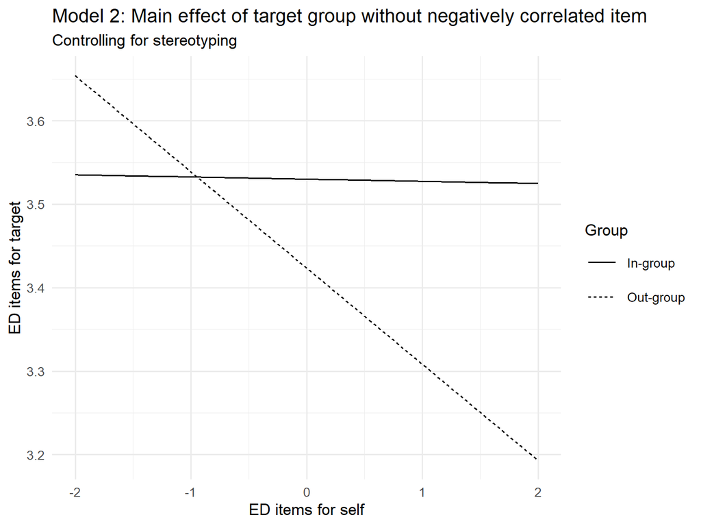

```r
model2group_plot_EDnodogs_wstereo <- get_groupME_proj_plot(model2ED_nodogs_wstereo)

model2group_plot_EDnodogs_wstereo +
  labs(title = "Model 2: Main effect of target group without negatively correlated item",
       subtitle = "Controlling for stereotyping",
       x = "ED items for self",
       y = "ED items for target",
       linetype = "Group")
```

Again, does not change the results.

## BFI w/ stereo model

```r
model2_bfistereo <- clean_ptcheck %>%
  select(sub_id, BFI_number, BFI_target_group, TargBFI, selfBFI_c, group_cond,
         opin_pol_combined, stereoBFI_c) %>%
  # changing name for plot function
  mutate(self_c = selfBFI_c) %>%
  na.omit() %>%
  unique()
```

### Results

```r
model2_bfistereo_resuts <- lmer(TargBFI ~ self_c*group_cond*stereoBFI_c + (self_c |sub_id), data = model2_bfistereo)

summary(model2_bfistereo_resuts)
```

```
## Linear mixed model fit by REML. t-tests use Satterthwaite's method [
## lmerModLmerTest]
## Formula: TargBFI ~ self_c * group_cond * stereoBFI_c + (self_c | sub_id)
##    Data: model2_bfistereo
##
## REML criterion at convergence: 33324.7
##
## Scaled residuals:
##     Min      1Q  Median      3Q     Max
## -3.8473 -0.6064  0.0455  0.6523  3.1696
##
## Random effects:
##  Groups   Name        Variance Std.Dev. Corr
##  sub_id   (Intercept) 0.07860  0.2804
##           self_c      0.04552  0.2133   0.40
##  Residual             0.92115  0.9598
## Number of obs: 11678, groups:  sub_id, 618
##
## Fixed effects:
##                                    Estimate   Std. Error           df t value
## (Intercept)                        3.333435     0.015040   697.688486 221.638
## self_c                             0.088252     0.011697   676.416478   7.545
## group_cond1                        0.143023     0.015040   697.688486   9.509
## stereoBFI_c                        0.338984     0.008860 11536.096846  38.260
## self_c:group_cond1                 0.068297     0.011697   676.416478   5.839
## self_c:stereoBFI_c                -0.005448     0.006487 11524.372160  -0.840
## group_cond1:stereoBFI_c            0.012923     0.008860 11536.096846   1.459
## self_c:group_cond1:stereoBFI_c    -0.014015     0.006487 11524.372160  -2.161
##                                            Pr(>|t|)
## (Intercept)                    < 0.0000000000000002 ***
## self_c                            0.000000000000146 ***
## group_cond1                    < 0.0000000000000002 ***
## stereoBFI_c                    < 0.0000000000000002 ***
## self_c:group_cond1                0.000000008152985 ***
## self_c:stereoBFI_c                           0.4010
## group_cond1:stereoBFI_c                      0.1447
## self_c:group_cond1:stereoBFI_c               0.0307 *
## ---
## Signif. codes:  0 '***' 0.001 '**' 0.01 '*' 0.05 '.' 0.1 ' ' 1
##
## Correlation of Fixed Effects:
##             (Intr) self_c grp_c1 stBFI_ sl_:_1 s_:BFI g_1:BF
## self_c       0.288
## group_cond1  0.013  0.019
## stereoBFI_c -0.058 -0.034 -0.228
## slf_c:grp_1  0.019  0.011  0.288 -0.166
## slf_c:sBFI_ -0.028 -0.054 -0.157  0.075 -0.179
## grp_c1:BFI_ -0.228 -0.166 -0.058  0.244 -0.034  0.011
## sl_:_1:BFI_ -0.157 -0.179 -0.028  0.011 -0.054  0.211  0.075
```

```r
confint(model2_bfistereo_resuts)
```

```
##                                       2.5 %       97.5 %
## .sig01                          0.254164147  0.306315302
## .sig02                          0.279183315  0.521587776
## .sig03                          0.192670393  0.233822267
## .sigma                          0.946751410  0.972756695
## (Intercept)                     3.303970197  3.362914323
## self_c                          0.065320838  0.111187705
## group_cond1                     0.113571036  0.172529227
## stereoBFI_c                     0.321603166  0.356502394
## self_c:group_cond1              0.045371055  0.091206419
## self_c:stereoBFI_c             -0.018212631  0.007332940
## group_cond1:stereoBFI_c        -0.004454195  0.030293696
## self_c:group_cond1:stereoBFI_c -0.026776107 -0.001306427
```

Model failed to converge when allowing stereotyping to have random slopes as well, so only included self as random slopes.

The main effect of selfBFI_c:group_cond did not disappear when including stereotyping as a moderator, replicating that aspect of the exploratory results from Study 1 (my FYP), and there was no interaction of stereotyping*target group on projection. However, there is a three-way interaction that we need to consider, and we need to consider how the plots look.

### Plots

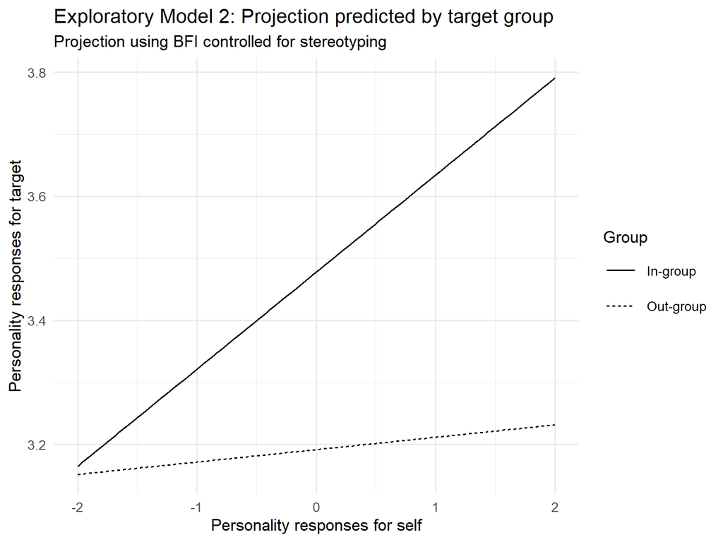

```r
knitr::opts_chunk$set(fig.width = 8, fig.height = 6)

model2group_plot_bfistereo <- get_groupME_proj_plot(model2_bfistereo_resuts)

model2group_plot_bfistereo +
  labs(title = "Exploratory Model 2: Projection predicted by target group",
       subtitle = "Projection using BFI controlled for stereotyping",
       x = "Personality responses for self",
       y = "Personality responses for target",
       linetype = "Group")
```

```r
# ggpreview(width = 8, height = 6, units = "in")
```

When controlling for stereotyping, the counter projection found earlier does disappear. This is in contrast with the exploratory results of my FYP with MFQ.

```r
describe(model2_bfistereo$stereoBFI_c)
```

```
##    vars     n mean   sd median trimmed  mad   min  max range  skew kurtosis
## X1    1 11678    0 1.22  -0.03    0.01 1.48 -2.03 1.97     4 -0.09    -0.89
##      se
## X1 0.01
```

```r
model2_bfistereo_int_effects <- effect(term = "self_c:group_cond:stereoBFI_c",
                           xlevels = list(group_cond = c("In-group",
                                                         "Out-group"),
                                         stereoBFI_c = c(-1.22, 0, 1.22)),
                           mod = model2_bfistereo_resuts)

model2_bfistereo_int_effects <- as.data.frame(model2_bfistereo_int_effects)

model2_bfistereo_int_effects %<>%
  mutate(Stereotyping = as.factor(stereoBFI_c),
         Stereotyping = dplyr::recode(Stereotyping,
                                      `-1.22` =
                                        "Low stereotyping \n (1 SD below)",
                                      `0` =
                                        "Average stereotyping",
                                      `1.22` =
                                        "High stereotyping  \n(1 SD above)"))
```

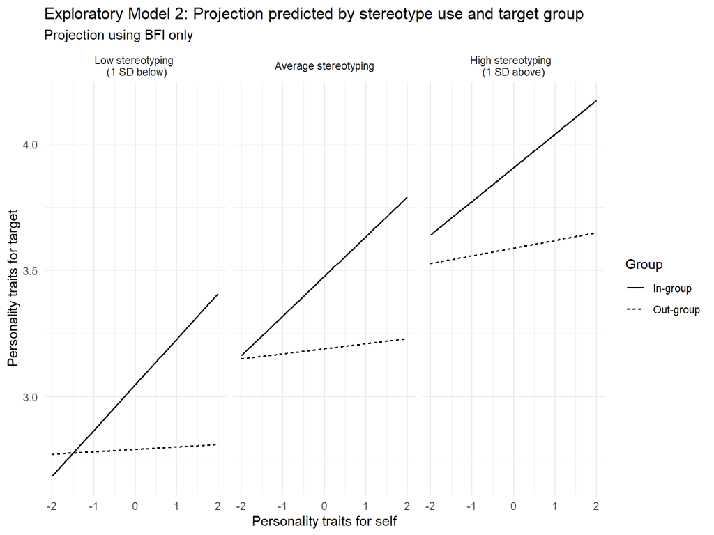

```r
knitr::opts_chunk$set(fig.width = 8, fig.height = 6)

ggplot(model2_bfistereo_int_effects, aes(self_c,
                                     fit,
                                     group = group_cond,
                                     colour = group_cond)) +
  geom_smooth(method = "lm", se = FALSE, size = .7, colour = "black",
              aes(linetype = group_cond)) +
  facet_grid(cols = vars(Stereotyping)) +
  theme_minimal() +
  labs(title = "Exploratory Model 2: Projection predicted by stereotype use and target group",
       subtitle = "Projection using BFI only",
       x = "Personality traits for self",
       y = "Personality traits for target",
       linetype = "Group")
```

```r
# ggpreview(width = 8, height = 6, units = "in")
```

### Effects codes applied to all data-sets

```r
contrasts(model2ED_data$group_cond) <- contr.sum(2)
contrasts(model2ED_data$group_cond)
```

```
##           [,1]
## In-group     1
## Out-group   -1
```

## BFI + ED w/o stereo model

### Results

```r
model2EDBFI_nostereo <- lmer(Targ ~ self_c*group_cond + (self_c|sub_id),
               data = EDBFI_mod2)
summary(model2EDBFI_nostereo)
```

```
## Linear mixed model fit by REML. t-tests use Satterthwaite's method [
## lmerModLmerTest]
## Formula: Targ ~ self_c * group_cond + (self_c | sub_id)
##    Data: EDBFI_mod2
##
## REML criterion at convergence: 86131.8
##
## Scaled residuals:
##     Min      1Q  Median      3Q     Max
## -3.6903 -0.6062  0.0533  0.6753  3.5452
##
## Random effects:
##  Groups   Name        Variance Std.Dev. Corr
##  sub_id   (Intercept) 0.11049  0.3324
##           self_c      0.06898  0.2626   0.36
##  Residual             1.00646  1.0032
## Number of obs: 29514, groups:  sub_id, 618
##
## Fixed effects:
##                     Estimate Std. Error        df t value             Pr(>|t|)
## (Intercept)          3.33460    0.01466 615.59617 227.455 < 0.0000000000000002
## self_c               0.06343    0.01166 620.12801   5.439         0.0000000774
## group_cond1          0.22719    0.01466 615.59617  15.497 < 0.0000000000000002
## self_c:group_cond1   0.12944    0.01166 620.12801  11.099 < 0.0000000000000002
##
## (Intercept)        ***
## self_c             ***
## group_cond1        ***
## self_c:group_cond1 ***
## ---
## Signif. codes:  0 '***' 0.001 '**' 0.01 '*' 0.05 '.' 0.1 ' ' 1
##
## Correlation of Fixed Effects:
##             (Intr) self_c grp_c1
## self_c       0.297
## group_cond1 -0.006  0.001
## slf_c:grp_1  0.001 -0.005  0.297
```

```r
confint(model2EDBFI_nostereo)
```

```
##                         2.5 %     97.5 %
## .sig01             0.31037680 0.35497113
## .sig02             0.27048486 0.44052696
## .sig03             0.24512112 0.28055141
## .sigma             0.99501535 1.01155154
## (Intercept)        3.30586678 3.36333355
## self_c             0.04057112 0.08628778
## group_cond1        0.19846141 0.25593183
## self_c:group_cond1 0.10657210 0.15228738
```

### Plots

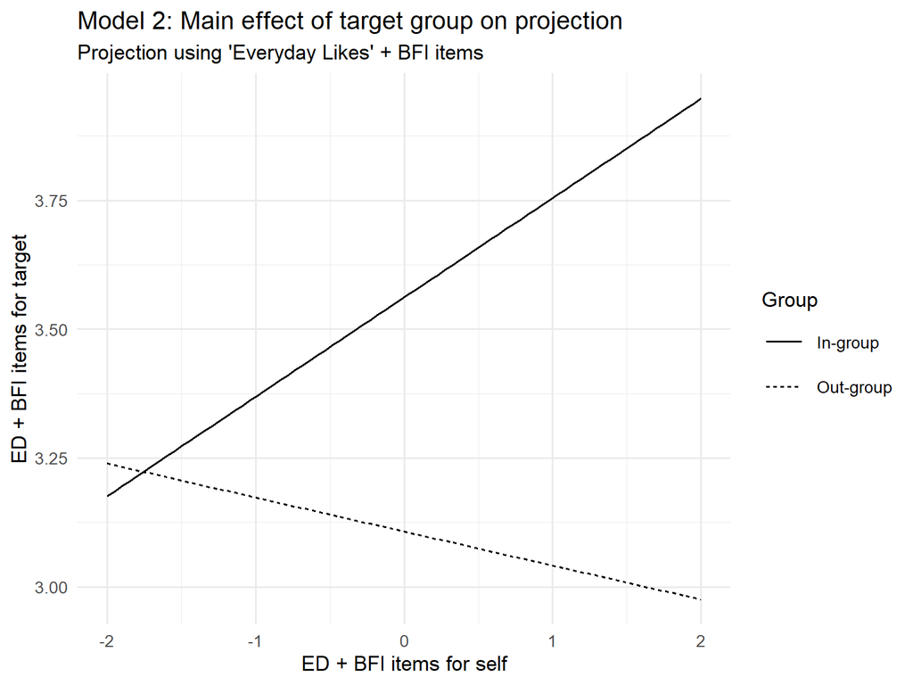

```r
model2group_plot_EDBFI_nostereo <- get_groupME_proj_plot(model2EDBFI_nostereo)

model2group_plot_EDBFI_nostereo +
  labs(title = "Model 2: Main effect of target group on projection",
       subtitle = "Projection using 'Everyday Likes' + BFI items",
         x = "ED + BFI items for self",
         y = "ED + BFI items for target",
       linetype = "Group")
```

With everyday likes added to the BFI, the main effect of target group on projection does not change from Model 1 (there is still counter projection).

# Pre-reg Model 2: ED + BFI w/ stereotyping

**Added stereotyping and everyday likes to Model 1 to see if it adding it changed counter projection.**

## Results

```r
model2EDBFI_stereo <- lmer(Targ ~ self_c*group_cond*stereo_c + (self_c|sub_id),
               data = EDBFI_mod2)

summary(model2EDBFI_stereo)
```

```
## Linear mixed model fit by REML. t-tests use Satterthwaite's method [
## lmerModLmerTest]
## Formula: Targ ~ self_c * group_cond * stereo_c + (self_c | sub_id)
##    Data: EDBFI_mod2
##
## REML criterion at convergence: 82205.2
##
## Scaled residuals:
##     Min      1Q  Median      3Q     Max
## -4.0667 -0.5854  0.0362  0.6522  3.9449
##
## Random effects:
##  Groups   Name        Variance Std.Dev. Corr
##  sub_id   (Intercept) 0.07820  0.2796
##           self_c      0.05094  0.2257   0.32
##  Residual             0.88558  0.9411
## Number of obs: 29514, groups:  sub_id, 618
##
## Fixed effects:
##                                 Estimate   Std. Error           df t value
## (Intercept)                     3.333512     0.012772   648.853666 261.005
## self_c                          0.060056     0.010294   640.727997   5.834
## group_cond1                     0.120062     0.012772   648.853666   9.400
## stereo_c                        0.351565     0.005611 29372.196569  62.661
## self_c:group_cond1              0.065724     0.010294   640.727997   6.385
## self_c:stereo_c                -0.004830     0.004096 29330.223809  -1.179
## group_cond1:stereo_c            0.005018     0.005611 29372.196566   0.894
## self_c:group_cond1:stereo_c    -0.002611     0.004096 29330.223809  -0.637
##                                         Pr(>|t|)
## (Intercept)                 < 0.0000000000000002 ***
## self_c                             0.00000000859 ***
## group_cond1                 < 0.0000000000000002 ***
## stereo_c                    < 0.0000000000000002 ***
## self_c:group_cond1                 0.00000000033 ***
## self_c:stereo_c                            0.238
## group_cond1:stereo_c                       0.371
## self_c:group_cond1:stereo_c                0.524
## ---
## Signif. codes:  0 '***' 0.001 '**' 0.01 '*' 0.05 '.' 0.1 ' ' 1
##
## Correlation of Fixed Effects:
##             (Intr) self_c grp_c1 ster_c sl_:_1 slf_:_ gr_1:_
## self_c       0.277
## group_cond1  0.004  0.010
## stereo_c    -0.042 -0.036 -0.142
## slf_c:grp_1  0.010  0.004  0.277 -0.108
## slf_c:str_c -0.031 -0.035 -0.105  0.059 -0.101
## grp_cnd1:s_ -0.142 -0.108 -0.042  0.283 -0.036  0.025
## slf_c:g_1:_ -0.105 -0.101 -0.031  0.025 -0.035  0.243  0.059
```

```r
confint(model2EDBFI_stereo)
```

```
##                                    2.5 %      97.5 %
## .sig01                       0.260245753 0.299389833
## .sig02                       0.229845727 0.410421845
## .sig03                       0.210050091 0.241612369
## .sigma                       0.933289047 0.948801309
## (Intercept)                  3.308487759 3.358545126
## self_c                       0.039882840 0.080232220
## group_cond1                  0.095042391 0.145101268
## stereo_c                     0.340573372 0.362617382
## self_c:group_cond1           0.045546358 0.085891232
## self_c:stereo_c             -0.012875051 0.003218792
## group_cond1:stereo_c        -0.005979234 0.016017333
## self_c:group_cond1:stereo_c -0.010654622 0.005410773
```

When stereotyping is added as a random slope, the model does not converge. Thus, we chose to only include self as a random slope.

When ED and BFI are combined, there is no significant three-way interaction with stereotyping, self, and group. With stereotyping included as a moderator, the effect of target group on projection is still significant. The effect of group on stereotyping is not significant, which relates to our Prediction #2, discussed with the plot.

## Plots

```r
mod2EDBFI_targ_stereo_effects <- effect(term = "group_cond:stereo_c",
                           xlevels = list(group_cond = c("In-group",
                                                         "Out-group")),
                           mod = model2EDBFI_stereo)

mod2EDBFI_targ_stereo_effects <- as.data.frame(mod2EDBFI_targ_stereo_effects)
```

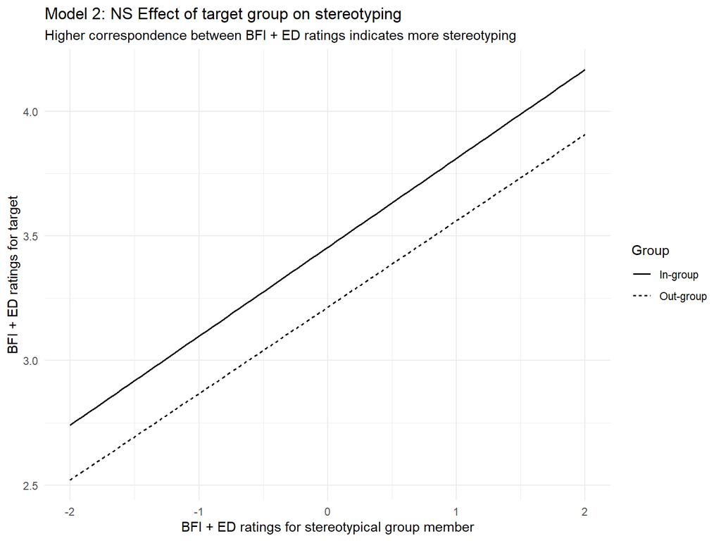

```r
ggplot(mod2EDBFI_targ_stereo_effects, aes(stereo_c, fit, group = group_cond)) +
  geom_smooth(method = "lm",
              se = FALSE,
              size = .7,
              colour = "black",
              aes(linetype = group_cond)) +
  theme_minimal() +
  labs(title = "Model 2: NS Effect of target group on stereotyping",
       subtitle = "Higher correspondence between BFI + ED ratings indicates more stereotyping",
       y = "BFI + ED ratings for target",
       x = "BFI + ED ratings for stereotypical group member",
       linetype = "Group")
```

People stereotype their in-group and out-group to a similar extent, but the intercept differs. This does not support our Confirmatory Prediction #2: “People will stereotype the out-group target more than the in-group target due to out-group homogeneity.”

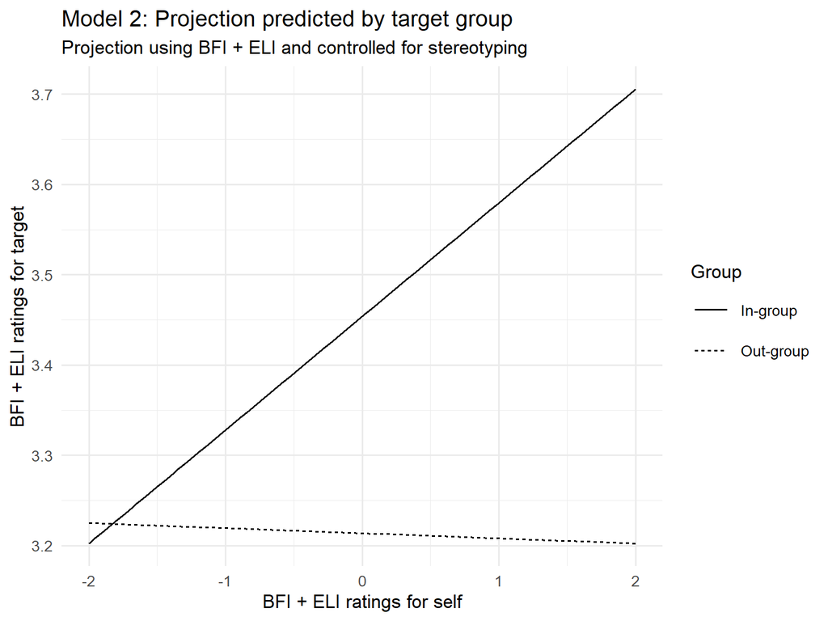

```r
knitr::opts_chunk$set(fig.width = 8, fig.height = 6)

model2group_plot_EDBFI_stereo <- get_groupME_proj_plot(model2EDBFI_stereo)

model2group_plot_EDBFI_stereo +
  labs(title = "Model 2: Projection predicted by target group",
       subtitle = "Projection using BFI + ELI and controlled for stereotyping",
       y = "BFI + ELI ratings for target",
       x = "BFI + ELI ratings for self",
       linetype = "Group")
```

```r
# ggpreview(width = 8, height = 6, units = "in")
```

When everyday likes items are added to the BFI, even with stereotyping controlled for in the model, we see slight counter projection with the out-group target. This corresponds with Confirmatory Prediction #3: “even with stereotyping as a predictor, projection will still explain variance in ratings of the target, producing the significant main effect predicted above and no model singularities (in other words, how the participant rates the Self and the Stereotypical target will each predict unique variance in ratings of the target; moreover, the model with both of predictors included will not be singular). Although stereotyping may interact with projection as well (we found this in an earlier study), we do not expect the projection-only effects to go away.”

Interestingly, we did not find an interaction of stereotyping with projection in our confirmatory results. As demonstrated by our exploratory heirarchdal build-up models, counter projection is driven by ED when stereotyping is included in the model, as there does not appear to be a stereotype for ED like there is for BFI to moderate counter projection with BFI.

# Model 3: Identification as moderator

## Pre-registered Confirmatory Model

**Our pre-registered model used the BFI only, as we pre-registered we would use the BFI only if we found there were differences in the data-sets of the BFI and ED. We also pre-registered we would drop stereotyping to conserve power.**

### Data note:

```r
dataBFI_mod3  <- clean_ptcheck %>%
  select(sub_id, BFI_number, BFI_target_group, TargBFI, selfBFI_c, group_cond,
         opin_pol_combined, stereoBFI_c, identification_c) %>%
  # changing name for plot function
  mutate(self_c = selfBFI_c) %>%
  na.omit() %>%
  unique()

dataBFI_mod3 %>%
  select(sub_id) %>%
  unique() %>%
  nrow()
```

```
## [1] 616
```

2 participants dropped due to missing data in identification.

### Results

#### Contrasts

```r
model3BFI_nostereo <- lmer(TargBFI ~ self_c*group_cond*identification_c + (self_c|sub_id),
               data = dataBFI_mod3)

summary(model3BFI_nostereo)
```

```
## Linear mixed model fit by REML. t-tests use Satterthwaite's method [
## lmerModLmerTest]
## Formula: TargBFI ~ self_c * group_cond * identification_c + (self_c |
##     sub_id)
##    Data: dataBFI_mod3
##
## REML criterion at convergence: 34610.5
##
## Scaled residuals:
##     Min      1Q  Median      3Q     Max
## -3.4008 -0.6046  0.0471  0.6750  2.9902
##
## Random effects:
##  Groups   Name        Variance Std.Dev. Corr
##  sub_id   (Intercept) 0.11100  0.3332
##           self_c      0.06347  0.2519   0.41
##  Residual             1.02383  1.0118
## Number of obs: 11640, groups:  sub_id, 616
##
## Fixed effects:
##                                        Estimate  Std. Error          df t value
## (Intercept)                           3.3354707   0.0165235 611.2283598 201.863
## self_c                                0.0844532   0.0128763 618.9184755   6.559
## group_cond1                           0.2658202   0.0165235 611.2283598  16.087
## identification_c                      0.0001631   0.0130318 613.5344764   0.013
## self_c:group_cond1                    0.1341349   0.0128763 618.9184755  10.417
## self_c:identification_c               0.0027027   0.0100983 607.7245577   0.268
## group_cond1:identification_c          0.0449056   0.0130318 613.5344764   3.446
## self_c:group_cond1:identification_c   0.0219580   0.0100983 607.7245577   2.174
##                                                 Pr(>|t|)
## (Intercept)                         < 0.0000000000000002 ***
## self_c                                    0.000000000115 ***
## group_cond1                         < 0.0000000000000002 ***
## identification_c                                0.990020
## self_c:group_cond1                  < 0.0000000000000002 ***
## self_c:identification_c                         0.789069
## group_cond1:identification_c                    0.000608 ***
## self_c:group_cond1:identification_c             0.030059 *
## ---
## Signif. codes:  0 '***' 0.001 '**' 0.01 '*' 0.05 '.' 0.1 ' ' 1
##
## Correlation of Fixed Effects:
##             (Intr) self_c grp_c1 idntf_ sl_:_1 slf_:_ gr_1:_
## self_c       0.267
## group_cond1 -0.005  0.003
## identfctn_c -0.004 -0.013  0.013
## slf_c:grp_1  0.003 -0.006  0.267  0.007
## slf_c:dntf_ -0.013 -0.006  0.007  0.270  0.010
## grp_cnd1:d_  0.013  0.007 -0.004  0.023 -0.013  0.015
## slf_c:g_1:_  0.007  0.010 -0.013  0.015 -0.006  0.027  0.270
```

```r
confint(model3BFI_nostereo)
```

```
##                                            2.5 %     97.5 %
## .sig01                               0.304135706 0.36068589
## .sig02                               0.298634785 0.51735466
## .sig03                               0.229238227 0.27340162
## .sigma                               0.998276400 1.02572069
## (Intercept)                          3.303151898 3.36781243
## self_c                               0.059231495 0.10964815
## group_cond1                          0.233533702 0.29822707
## identification_c                    -0.025358486 0.02564264
## self_c:group_cond1                   0.108922217 0.15932874
## self_c:identification_c             -0.017057109 0.02246303
## group_cond1:identification_c         0.019407924 0.07040353
## self_c:group_cond1:identification_c  0.002204488 0.04171908
```

### Plots

```r
describe(dataBFI_mod3$identification_c)
```

```
##    vars     n mean   sd median trimmed  mad   min  max range  skew kurtosis
## X1    1 11640    0 1.27   0.61     0.1 1.48 -2.39 1.61     4 -0.43    -0.79
##      se
## X1 0.01
```

```r
mod3BFInostereo_proj_ident_group_effects <- effect(term = "self_c:group_cond:identification_c",
                           xlevels = list(group_cond = c("In-group",
                                                         "Out-group"),
                                         identification_c = c(-1.27, 0, 1.27)),
                           mod = model3BFI_nostereo)

mod3BFInostereo_proj_ident_group_effects<- as.data.frame(mod3BFInostereo_proj_ident_group_effects)

mod3BFInostereo_proj_ident_group_effects %<>%
  mutate(Identification = as.factor(identification_c),
         Identification = dplyr::recode(Identification,
                                         `-1.27` = "Low identification \n (1 SD below)",
                                         `0` = "Average \n identification",
                                         `1.27` = "High identificaiton \n (1 SD above)"))
```

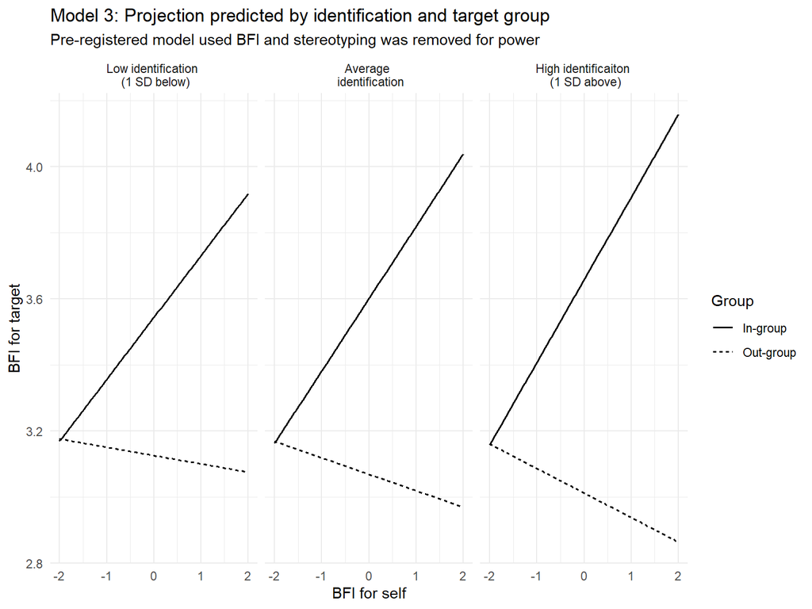

```r
knitr::opts_chunk$set(fig.width = 8, fig.height = 6)

ggplot(mod3BFInostereo_proj_ident_group_effects, aes(self_c,
                                     fit,
                                     group = group_cond,
                                     colour = group_cond)) +
  geom_smooth(method = "lm",
              se = FALSE,
              size = .7,
              colour = "black",
              aes(linetype = group_cond)) +
  facet_grid(cols = vars(Identification)) +
  theme_minimal() +
  labs(title = "Model 3: Projection predicted by identification and target group",
       subtitle = "Pre-registered model used BFI and stereotyping was removed for power",
       x = "BFI for self",
       y = "BFI for target",
       linetype = "Group")
```

```r
# ggpreview(width = 8, height = 6, units = "in")
```

As identification increases, out-group counter projection increases as well as in-group projection.

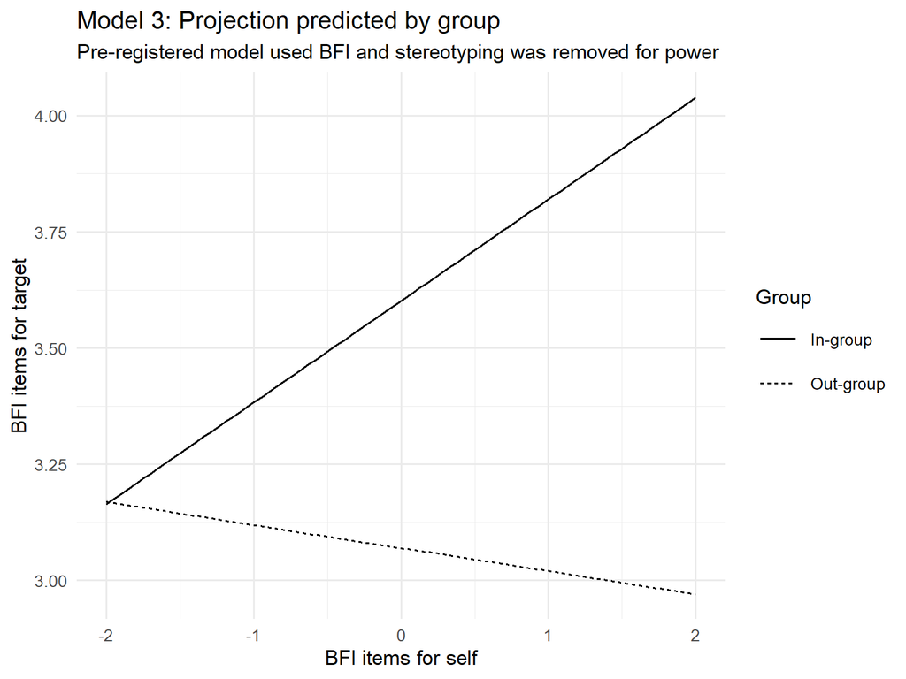

```r
knitr::opts_chunk$set(fig.width = 8, fig.height = 6)

mod3BFI_nostereo_proj_group_plot <- get_groupME_proj_plot(model3BFI_nostereo)

mod3BFI_nostereo_proj_group_plot +
  labs(title = "Model 3: Projection predicted by group",
       subtitle = "Pre-registered model used BFI and stereotyping was removed for power",
         x = "BFI items for self",
         y = "BFI items for target",
         linetype = "Group")
```

```r
# ggpreview(width = 8, height = 6, units = "in")
```

Without stereotyping and only using BFI, we see counter projection for out-group targets and regular projection for in-group targets.

```r
mod3BFI_nostereo_proj_ident <- effect(term = "self_c:identification_c",
                           xlevels = list(identification_c = c(-1.27, 0, 1.27)),
                           mod = model3BFI_nostereo)

mod3BFI_nostereo_proj_ident <- as.data.frame(mod3BFI_nostereo_proj_ident)

mod3BFI_nostereo_proj_ident %<>%
  mutate(Identification = as.factor(identification_c))
```

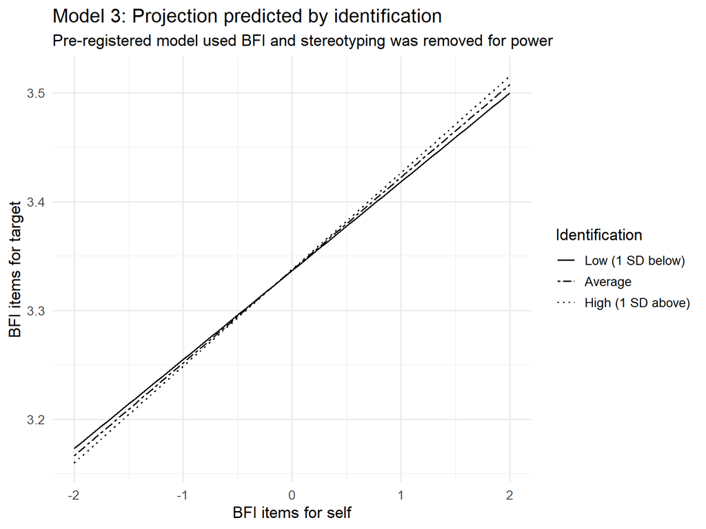

```r
knitr::opts_chunk$set(fig.width = 8, fig.height = 6)

ggplot(mod3BFI_nostereo_proj_ident, aes(self_c, fit, group = Identification)) +
  geom_smooth(method = "lm",
              se = FALSE,
              size = .7,
              colour = "black",
              aes(linetype = Identification)) +
  theme_minimal(base_size = 13) +
  labs(title = "Model 3: Projection predicted by identification",
       subtitle = "Pre-registered model used BFI and stereotyping was removed for power",
         x = "BFI items for self",
         y = "BFI items for target") +
  scale_linetype_manual("Identification", breaks = c(-1.27, 0, 1.27),
                       labels = c("Low (1 SD below)",
                                  "Average",
                                  "High (1 SD above)"),
                       values = c("solid",
                                   "twodash",
                                   "dotted"))
```

```r
# ggpreview(width = 8, height = 6, units = "in")
```

On lower scores for BFI, there is less difference in projection between identification groups. As ED and BFI scores increase, you see more projection in high identifiers compared to average and then low identifiers.

## BFI w/ stereo

### Results

```r
model3BFI_stereo <- lmer(TargBFI ~ self_c*group_cond*stereoBFI_c*identification_c + (self_c|sub_id), data = dataBFI_mod3)

summary(model3BFI_stereo)
```

```
## Linear mixed model fit by REML. t-tests use Satterthwaite's method [
## lmerModLmerTest]
## Formula: TargBFI ~ self_c * group_cond * stereoBFI_c * identification_c +
##     (self_c | sub_id)
##    Data: dataBFI_mod3
##
## REML criterion at convergence: 33199.1
##
## Scaled residuals:
##     Min      1Q  Median      3Q     Max
## -3.7918 -0.6054  0.0403  0.6496  3.3106
##
## Random effects:
##  Groups   Name        Variance Std.Dev. Corr
##  sub_id   (Intercept) 0.07888  0.2809
##           self_c      0.04681  0.2164   0.41
##  Residual             0.91416  0.9561
## Number of obs: 11640, groups:  sub_id, 616
##
## Fixed effects:
##                                                     Estimate   Std. Error
## (Intercept)                                         3.331595     0.015068
## self_c                                              0.088838     0.011792
## group_cond1                                         0.141888     0.015068
## stereoBFI_c                                         0.337062     0.008885
## identification_c                                   -0.010361     0.011934
## self_c:group_cond1                                  0.067435     0.011792
## self_c:stereoBFI_c                                 -0.007061     0.006495
## group_cond1:stereoBFI_c                             0.012081     0.008885
## self_c:identification_c                             0.000337     0.009256
## group_cond1:identification_c                        0.012769     0.011934
## stereoBFI_c:identification_c                        0.037562     0.006907
## self_c:group_cond1:stereoBFI_c                     -0.015276     0.006495
## self_c:group_cond1:identification_c                 0.007969     0.009256
## self_c:stereoBFI_c:identification_c                -0.005257     0.004966
## group_cond1:stereoBFI_c:identification_c            0.012140     0.006907
## self_c:group_cond1:stereoBFI_c:identification_c     0.002403     0.004966
##                                                           df t value
## (Intercept)                                       692.768309 221.099
## self_c                                            670.974001   7.534
```

[output cut: 18 more lines]

```
## stereoBFI_c                                     < 0.0000000000000002 ***
## identification_c                                              0.3856
## self_c:group_cond1                                  0.00000001615093 ***
## self_c:stereoBFI_c                                            0.2770
## group_cond1:stereoBFI_c                                       0.1739
## self_c:identification_c                                       0.9710
## group_cond1:identification_c                                  0.2850
## stereoBFI_c:identification_c                        0.00000005482110 ***
## self_c:group_cond1:stereoBFI_c                                0.0187 *
## self_c:group_cond1:identification_c                           0.3896
## self_c:stereoBFI_c:identification_c                           0.2898
## group_cond1:stereoBFI_c:identification_c                      0.0788 .
## self_c:group_cond1:stereoBFI_c:identification_c               0.6285
## ---
## Signif. codes:  0 '***' 0.001 '**' 0.01 '*' 0.05 '.' 0.1 ' ' 1
```

```r
confint(model3BFI_stereo)
```

```
##                                                        2.5 %       97.5 %
## .sig01                                           0.253831932  0.305973461
## .sig02                                           0.282397997  0.523492227
## .sig03                                           0.195022849  0.236194335
## .sigma                                           0.942972284  0.968922396
## (Intercept)                                      3.302146892  3.361099938
## self_c                                           0.065752492  0.111906459
## group_cond1                                      0.112433427  0.171395380
## stereoBFI_c                                      0.319710610  0.354695089
## identification_c                                -0.033713720  0.012968330
## self_c:group_cond1                               0.044356675  0.090478935
## self_c:stereoBFI_c                              -0.019835720  0.005738920
## group_cond1:stereoBFI_c                         -0.005339589  0.029493674
## self_c:identification_c                         -0.017761288  0.018446565
## group_cond1:identification_c                    -0.010566933  0.036117896
## stereoBFI_c:identification_c                     0.023937983  0.051054077
## self_c:group_cond1:stereoBFI_c                  -0.028076881 -0.002581643
## self_c:group_cond1:identification_c             -0.010125093  0.026079731
## self_c:stereoBFI_c:identification_c             -0.015007039  0.004479128
## group_cond1:stereoBFI_c:identification_c        -0.001440437  0.025635335
## self_c:group_cond1:stereoBFI_c:identification_c -0.007324580  0.012144308
```

When BFI is added to a model controlled by stereotyping, the interaction between condition and identification on projection disappears. There is a significant main effect of identification on stereotyping as well as group on projection. In addition, there is a significant interaction of stereotyping and group on projection. There is also a marginal interaction of group and identification on stereotyping.

### Plots

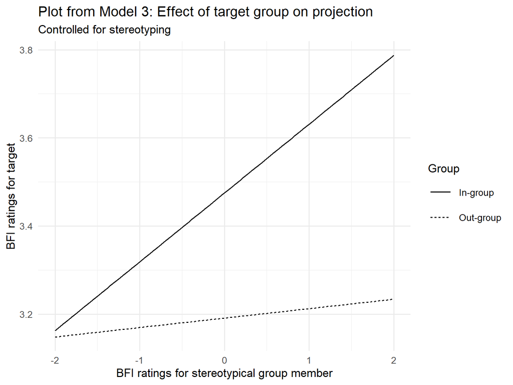

```r
mod3BFI_stereo_group_plot <- get_groupME_proj_plot(model3BFI_stereo)

mod3BFI_stereo_group_plot +
  labs(title = "Plot from Model 3: Effect of target group on projection",
       subtitle = "Controlled for stereotyping",
       y = "BFI ratings for target",
       x = "BFI ratings for stereotypical group member",
       linetype = "Group")
```

Projection main effect results are the same as the exploratory model from Model 2 of the BFI with stereotyping in which stereotyping removes counter projection with out-group targets.

```r
describe(dataBFI_mod3$stereoBFI_c)
```

```
##    vars     n mean   sd median trimmed  mad   min  max range  skew kurtosis
## X1    1 11640    0 1.22  -0.03    0.01 1.48 -2.03 1.97     4 -0.09    -0.89
##      se
## X1 0.01
```

```r
describe(dataBFI_mod3$identification_c)
```

```
##    vars     n mean   sd median trimmed  mad   min  max range  skew kurtosis
## X1    1 11640    0 1.27   0.61     0.1 1.48 -2.39 1.61     4 -0.43    -0.79
##      se
## X1 0.01
```

```r
mod3BFIstereo_3way_effects <- effect(term = "self_c:stereoBFI_c:identification_c",
                           xlevels = list(identification_c = c(-1.27, 0, 1.27),
                                          stereoBFI_c = c(-1.22, 0, 1.22)),
                           mod = model3BFI_stereo)

mod3BFIstereo_3way_effects <- as.data.frame(mod3BFIstereo_3way_effects)

mod3BFIstereo_3way_effects %<>%
  mutate(Identification = as.factor(identification_c),
         Stereotyping = as.factor(stereoBFI_c),
         Stereotyping = dplyr::recode(Stereotyping,
                                      `-1.22` = "Low stereotyping \n (1 SD below)",
                                      `0` = "Average \n stereotyping",
                                      `1.22` = "High stereotyping \n (1 SD above"))
```

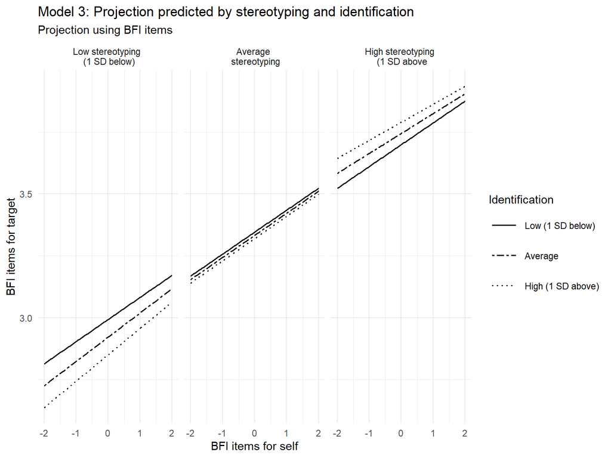

```r
ggplot(mod3BFIstereo_3way_effects, aes(self_c,
                                      fit,
                                      group = Identification,
                                      colour = Identification)) +
  geom_smooth(method = "lm", se = FALSE, size = .7, colour = "black",
              aes(linetype = Identification)) +
  facet_wrap(vars(Stereotyping)) +
  theme_minimal() +
  theme(legend.key.size = unit(1, "cm")) +
  labs(title = "Model 3: Projection predicted by stereotyping and identification",
       subtitle = "Projection using BFI items",
       x = "BFI items for self",
       y = "BFI items for target") +
    scale_linetype_manual("Identification", breaks = c(-1.27, 0, 1.27),
                       labels = c("Low (1 SD below)",
                                  "Average",
                                  "High (1 SD above)"),
                       values = c("solid",
                                   "twodash",
                                   "dotted"))
```

Collapsed across target group, people who apply less stereotypes to the target project more as in-group identification increases. Interestingly, people who demonstrate high use of stereotypes to the target exhibit the opposite pattern: low in-group identifiers project the most and as in-group identification increases, projection decreases. Average stereotype users all project around the same amount.

```r
mod3BFI_stereoME_ident <- effect(term = "stereoBFI_c:identification_c",
                           xlevels = list(identification_c = c(-1.27, 0, 1.27)),
                           mod = model3BFI_stereo)

mod3BFI_stereoME_ident <- as.data.frame(mod3BFI_stereoME_ident)

mod3BFI_stereoME_ident %<>%
  mutate(Identification = as.factor(identification_c))
```

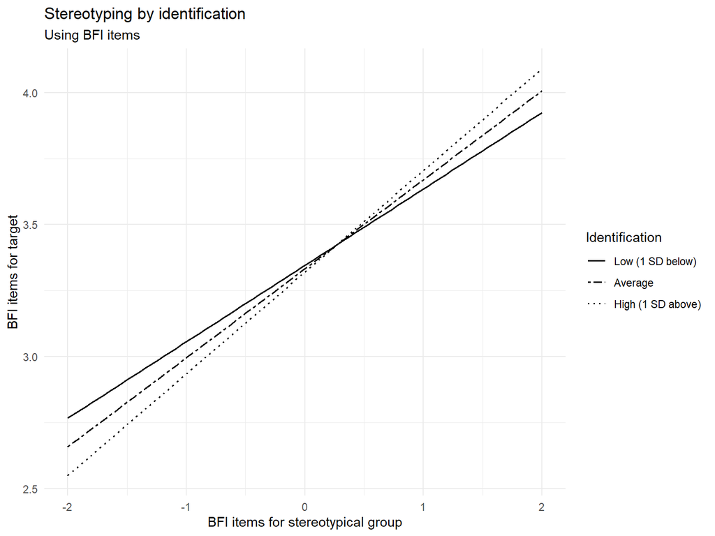

```r
ggplot(mod3BFI_stereoME_ident, aes(stereoBFI_c, fit, group = Identification, colour = Identification)) +
  geom_smooth(method = "lm", se = FALSE, size = .7, colour = "black",
              aes(linetype = Identification)) +
  theme(legend.key.size = unit(1, "cm")) +
  labs(title = "Stereotyping by identification",
       subtitle = "Using BFI items",
       x = "BFI items for stereotypical group",
       y = "BFI items for target") +
  theme_minimal() +
   scale_linetype_manual("Identification", breaks = c(-1.27, 0, 1.27),
                       labels = c("Low (1 SD below)",
                                  "Average",
                                  "High (1 SD above)"),
                       values = c("solid",
                                   "twodash",
                                   "dotted"))
```

As identification increases, stereotyping increases.

```r
mod3BFI_stereobygroupident <- effect(term = "group_cond:stereoBFI_c:identification_c",
                           xlevels = list(identification_c = c(-1.27, 0, 1.27),
                                          group_cond = c("In-group", "Out-group")),
                           mod = model3BFI_stereo)

mod3BFI_stereobygroupident <- as.data.frame(mod3BFI_stereobygroupident)

mod3BFI_stereobygroupident %<>%
  mutate(Identification = as.factor(identification_c),
         Identification = dplyr::recode(Identification,
                                         `-1.27` = "Low identification \n (1 SD below)",
                                         `0` = "Average \n identification",
                                         `1.27` = "High identification \n (1 SD above)"))
```

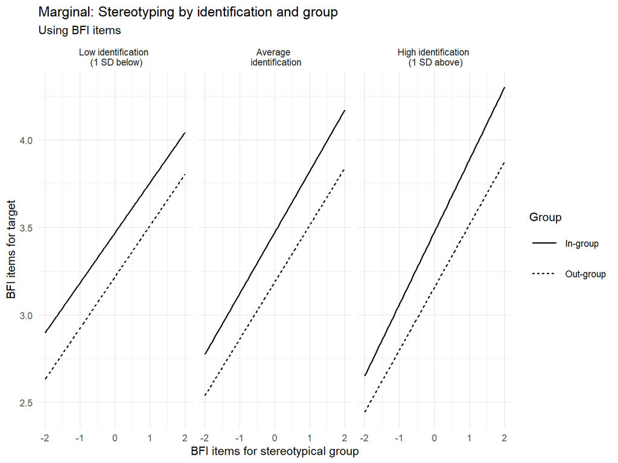

```r
ggplot(mod3BFI_stereobygroupident, aes(stereoBFI_c,
                                      fit,
                                      group = group_cond,
                                      colour = group_cond)) +
  geom_smooth(method = "lm", se = FALSE, size = .7, colour = "black",
              aes(linetype = group_cond)) +
  facet_wrap(vars(Identification)) +
  theme_minimal() +
  theme(legend.key.size = unit(1, "cm")) +
  labs(title = "Marginal: Stereotyping by identification and group",
       subtitle = "Using BFI items",
       x = "BFI items for stereotypical group",
       y = "BFI items for target",
       linetype = "Group")
```

This effect was marginal and appears to be driven by differences in stereotyping in high identifiers between target groups, in which they stereotype their in-group more than their out-group.

## ED w/o stereo

### Results

```r
model3ED_nostereo <- lmer(TargED ~ self_c*group_cond*identification_c + (self_c|sub_id),
               data = dataED_mod3)

summary(model3ED_nostereo)
```

```
## Linear mixed model fit by REML. t-tests use Satterthwaite's method [
## lmerModLmerTest]
## Formula: TargED ~ self_c * group_cond * identification_c + (self_c | sub_id)
##    Data: dataED_mod3
##
## REML criterion at convergence: 9043.7
##
## Scaled residuals:
##     Min      1Q  Median      3Q     Max
## -2.6908 -0.4767  0.1097  0.6695  2.5448
##
## Random effects:
##  Groups   Name        Variance Std.Dev. Corr
##  sub_id   (Intercept) 0.02910  0.1706
##           self_c      0.06739  0.2596   0.79
##  Residual             0.98717  0.9936
## Number of obs: 3069, groups:  sub_id, 616
##
## Fixed effects:
##                                       Estimate Std. Error         df t value
## (Intercept)                           3.346060   0.019771 617.191172 169.242
## self_c                               -0.018999   0.017904 544.417278  -1.061
## group_cond1                           0.093395   0.019771 617.191172   4.724
## identification_c                      0.028383   0.015519 609.935459   1.829
## self_c:group_cond1                    0.110242   0.017904 544.417278   6.158
## self_c:identification_c               0.001788   0.014008 533.288340   0.128
## group_cond1:identification_c          0.028635   0.015519 609.935459   1.845
## self_c:group_cond1:identification_c   0.023534   0.014008 533.288340   1.680
##                                                 Pr(>|t|)
## (Intercept)                         < 0.0000000000000002 ***
## self_c                                            0.2891
## group_cond1                                0.00000286746 ***
## identification_c                                  0.0679 .
## self_c:group_cond1                         0.00000000144 ***
## self_c:identification_c                           0.8985
## group_cond1:identification_c                      0.0655 .
## self_c:group_cond1:identification_c               0.0935 .
## ---
## Signif. codes:  0 '***' 0.001 '**' 0.01 '*' 0.05 '.' 0.1 ' ' 1
##
## Correlation of Fixed Effects:
##             (Intr) self_c grp_c1 idntf_ sl_:_1 slf_:_ gr_1:_
## self_c       0.166
## group_cond1 -0.004  0.021
## identfctn_c -0.003 -0.035  0.012
## slf_c:grp_1  0.021  0.008  0.166 -0.010
## slf_c:dntf_ -0.035 -0.024 -0.011  0.179  0.002
## grp_cnd1:d_  0.012 -0.010 -0.003  0.022 -0.035  0.015
## slf_c:g_1:_ -0.011  0.002 -0.035  0.015 -0.024  0.058  0.179
```

```r
confint(model3ED_nostereo)
```

```
##                                            2.5 %     97.5 %
## .sig01                               0.087403060 0.24055695
## .sig02                               0.411136263 0.95078207
## .sig03                               0.214043622 0.29935984
## .sigma                               0.963574676 1.02470875
## (Intercept)                          3.307389800 3.38473174
## self_c                              -0.053978873 0.01606886
## group_cond1                          0.054690675 0.13203766
## identification_c                    -0.001932430 0.05880620
## self_c:group_cond1                   0.075224820 0.14528365
## self_c:identification_c             -0.025662603 0.02918353
## group_cond1:identification_c        -0.001750098 0.05896742
## self_c:group_cond1:identification_c -0.003865942 0.05092741
```

When only using ED, the significant effect of group remains and there is a marginal interaction with identification.